# Applied Regression Using Stata but in R!

Nader Hotait

nhotait@uni-potsdam.de

Universität Potsdam

07.06.2020

# Stata Hausaufgaben

## Hausaufgabe 1

- **Download the datasets and do-files from the Kohler and Kreuter Book (2012).**

Dataset ist in folgendem Verzeichniz `D:\Office\Own Education\R\Übungen\Applied Regression Using Stata but in R!`

- **Load data1.dta and save a personal version of the dataset in your working directory.**

Hierfür laden wir zunächst das nötige Packet, um `read.csv` auszuführen. Im Anschluss können wir den Datensatz laden.

```r
library(readr)
data1 <- read.csv("data1.csv", header=TRUE, sep=",")
write.table(data1, file="data1_HA.csv", sep=";") ## Dieser Datensatz wird von Excel falsch geöffnet

library(writexl)
write_xlsx(data1, path="data1_HA.xlsx") ## Schon besser!
```

- **Create dummy variables for each level of education (variable $edu$).**

```r
data1$educ <- as.factor(data1$edu) ##Wir erstellen eine Variable, welche die Bildung als Factor beinhaltet
bild <- model.matrix(~data1$educ +0) ## Nun können wir eine  Matrix (Dummies) erstellen (+0 kein Intercept)
bild <- as.data.frame(bild) ## Diese speichern wir als Dataframe ab

library(dplyr)
library(tibble)
data1 <- bind_cols(data1,bild) ## Und kombinieren beide Datensätze zurück zum Ausgangsdatensatz
```

- **Create a variable that contains the size of one’s home (housing area) in square meters.**

```r
data1$size_m2 <- round((data1$size/10.7639), digits=0) ## Gerundet auf 0-Kommastellen (digits=0)
```

- **What is the average rent per square meter in West Germany ($state$)?**

```r
### East-West Dummy kreiren
data1$state <- as.character(data1$state)
east <- c("Mecklenburg-V.", "Brandenburg", "Saxony-Anhalt", "Thueringen", "Saxony")
data2 <- data1 %>% mutate(state = ifelse(state %in% east, 1L, 0L))
data1$west_east <- data2$state
data1$west_east[data1$sample == "C (East Germany)"] <- 1L

### Rent per Square Meter
missings <- as.factor(c(".a",".b",".c", ".d"))
data1$rent[data1$rent %in% missings] <- NA
data1$rent <- as.numeric(data1$rent)
data1$rent_sqm <- data1$rent/data1$size_m2

### Average Rent per square meter in West Germany
mean(data1$rent_sqm[data1$west_east==0], na.rm = TRUE)
```

```
## [1] 6.243343
```

- **Create a variable that contains the age of every person at the time the survey was conducted (in 2009).**

$Alter = Jahr\ der\ Erhebung_{2009} - Jahr\ der \ Geburt_{ybirth}$

```r
data1$age <- 2009-data1$ybirth
```

- **Create a dummy variable that depicts those who (1) live alone from (0) others.**

```r
data1$lives_alone <- data1$hhsize
data1$lives_alone[data1$lives_alone > 1] <- 0
summary(data1$lives_alone)
```

```
##    Min. 1st Qu.  Median    Mean 3rd Qu.    Max.
##  0.0000  0.0000  0.0000  0.1678  0.0000  1.0000
```

- **Reduce the categories of the EGP class status to: a combined service class, a combined non manual class, self employed people, and a combined manual working class. Recode the categories “retired” and “unemployed” as missing values (variable $egp$).**

```r
data1$egp_cut <- as.character(data1$egp)
data1$egp_cut[grep("Service class", data1$egp_cut)] <- "Service Class"
data1$egp_cut[grep(" manual workers", data1$egp_cut)] <- "Manual Class"
data1$egp_cut[grep("non-manuals", data1$egp_cut)] <- "Non-Manual Class"
data1$egp_cut[data1$egp_cut=="Retired"] <- NA
data1$egp_cut[data1$egp_cut=="unemployed"] <- NA
data1$egp_cut[data1$egp_cut=="Does not apply"] <- NA
data1$egp_cut[data1$egp_cut=="Refusal"] <- NA
table(data1$egp_cut)
```

```
##
##     Manual Class Non-Manual Class    Self-Employed    Service Class
##             1113              669              213             1093
```

- **Label this variable with 1 “service class”, 2 “non-manual class”, 3 “self-employed”, 4 “working class”.**

In *R* labeln wir nicht. Jedoch können wir die hinterlegte Variable als Faktor-Variable speichern!

```r
data1$egp_cut_fac <- as.factor(data1$egp_cut)
summary(data1$egp_cut_fac)
```

```
##     Manual Class Non-Manual Class    Self-Employed    Service Class
##             1113              669              213             1093
##             NA's
##             2323
```

```r
str(data1$egp_cut_fac)
```

```
##  Factor w/ 4 levels "Manual Class",..: NA NA NA 4 2 NA NA 2 1 4 ...
```

- **Creat a new income variable with the following income groups: 0 to 10000, 10001 to 20000, 20001 to 50000, 50001 to 100000.**

```r
data1$inc_cut <- data1$income
data1$inc_cut[between(data1$income, 0, 10000)] <- "0 to 10.000"
data1$inc_cut[between(data1$income, 10001, 20000)] <- "10.001 to 20.000"
data1$inc_cut[between(data1$income, 20001, 50000)] <- "20.001 to 50.000"
data1$inc_cut[between(data1$income, 50001, 100000)] <- "50.001 to 100.000"
data1$inc_cut[data1$income > 100000] <- "Over 100.000"
data1$inc_cut <- as.factor(data1$inc_cut)
summary(data1$inc_cut)
```

```
##       0 to 10.000  10.001 to 20.000  20.001 to 50.000 50.001 to 100.000
##              2219               666              1489               357
##      Over 100.000              NA's
##                48               632
```

- **Save your dataset and your do-file under a new name.**

```r
### Saving the Data
write_xlsx(data1, path="data1_HA.xlsx")

### Saving the script via  STRG + S, in code
```

## Hausaufgabe 2

- **Change your directory to your working directory and load data1:dta.**

Ist im Prinzip nicht nötig, weil ich innerhalb `D:\Office\Own Education\R\Übungen\Applied Regression Using Stata but in R!` arbeite. Jedoch würde der Code wie folgt aussehen:

```r
setwd("D:\\Office\\Own Education\\R\\Übungen\\Applied Regression Using Stata but in R!")
```

- **Create a variable (called $addwor$) that is an additive index of the variables measuring respondents’ worries about the future ($wor*$). Note: An additive index can easily be generated with egen and the option rowtotal.**

```r
## Krieren wir zunächst ein Rowtotal!
wor <- select(data1, starts_with("wor"))
wor <- wor %>% mutate_all(as.character)
glimpse(wor)
```

```
## Rows: 5,411
## Columns: 12
## $ wor01 <chr> "Very concerned", "Very concerned", "Somewhat concerned", "Ve...
## $ wor02 <chr> "Somewhat concerned", "Somewhat concerned", "Somewhat concern...
## $ wor03 <chr> "Very concerned", "Very concerned", "Somewhat concerned", "So...
## $ wor04 <chr> "Very concerned", "Very concerned", "Very concerned", "Somewh...
## $ wor05 <chr> "Very concerned", "Very concerned", "Somewhat concerned", "So...
## $ wor06 <chr> "Very concerned", "Very concerned", "Somewhat concerned", "So...
## $ wor07 <chr> "Somewhat concerned", "Somewhat concerned", "Somewhat concern...
## $ wor08 <chr> "Very concerned", "Very concerned", "Somewhat concerned", "So...
## $ wor09 <chr> "Very concerned", "Very concerned", "Very concerned", "Somewh...
## $ wor10 <chr> "Not concerned at all", "Not concerned at all", "Somewhat con...
## $ wor11 <chr> "Very concerned", "Very concerned", "Somewhat concerned", "So...
## $ wor12 <chr> "Does not apply", "Does not apply", "Does not apply", "Not co...
```

```r
wor[wor==""] <- NA
wor[wor=="Refusal"] <-NA
wor[wor=="Not concerned at all"] <- "0"
wor[wor=="Somewhat concerned"] <- "1"
wor[wor=="Very concerned"] <- "2"
wor[wor=="Does not apply"] <- NA
wor <- wor %>% mutate_all(as.numeric)

wor$addwor <- rowSums(wor[c(1:12)], na.rm = TRUE)
head(wor$addwor) ## Missings entwalten
```

```
## [1] 18 18 13 12 15 21
```

- **Replace this new var (called $addwor$) with a missing value (:) if any of the variables used ($wor*$) to generate the variable contains a missing value. Note: You could e.g. use egen and the option rowmiss for this.**

```r
##Wir können die Missings ausschließen mit na.rm = FALSE
wor$addwor <- rowSums(wor[c(1:12)], na.rm = FALSE)
head(wor$addwor) ##addwor = NA if wor* == NA
```

```
## [1] NA NA NA 12 15 NA
```

```r
##Aber jetzt nach ungefähren Logik wie es in der Aufgabenstelltung verlangt wird
wor$addwor <- rowSums(wor[c(1:12)], na.rm = TRUE) ## Variable in die Ausgangslange versetzt
wor$miss_wor <- complete.cases(wor[c(1:12)]) ## Indicator Variable, FALSE = Da sind Row-Missings
wor$addwor[wor$miss_wor == FALSE] <- NA
head(wor$addwor) ##addwor = NA if wor* == NA
```

```
## [1] NA NA NA 12 15 NA
```

```r
##Wir fügen diese Variable in data1 ein
data1$addwor <- wor$addwor
data1$miss_wor <- wor$miss_wor
```

- **What is the mean of this new var (called $addwor$)?**

```r
mean(data1$addwor, na.rm = TRUE)
```

```
## [1] 12.70903
```

- **Recode this variable with the goal that high values indicate more concerned people.**

Dies ist bereits geschehen als wir die Variablen umkodiert haben.

- **On average who worries more - female or male respondents ($sex$)?**

Frauen haben im durchschnitt eher Sorgen!

```r
mean(data1$addwor[data1$sex=="Male"], na.rm = TRUE)
```

```
## [1] 12.32838
```

```r
mean(data1$addwor[data1$sex=="Female"], na.rm = TRUE)
```

```
## [1] 13.10214
```

- **Please regress $addwor$ on a dummy var of sex (0=1). Please write a short interpretation of the coeff for $sex$ and the intercept.**

```r
reg1 <- lm(addwor ~ sex, data=data1)
reg1
```

```
##
## Call:
## lm(formula = addwor ~ sex, data = data1)
##
## Coefficients:
## (Intercept)      sexMale
##     13.1021      -0.7738
```

Die Refernzkategorie stellen Frauen dar. Heißt der Y-Achsenabschnitt meint den durchschnitt vont $addwor$ für Frauen. Der Regressionskoeffizient $\beta_{sex}$ bedeutet, dass Männer um 0,7738 Punkte des Indikators weniger Angst haben. Ausgerechnet heißt das:

```r
13.12021 - 0.7738
```

```
## [1] 12.34641
```

Beide Ergebnisse entsprechen in etwa dem Durchschnitt. Eine Einfach-Regression entspricht immer dem Durchschnitt der abhängigen Variable auf den Ebenen der Merkmale der unabhängigen Variable.

- **Controlling for gender, regress $addwor$ on years of education ($yedu$) and age. Note: To interpret the intercept in a meaningful manner, you need to center metric independent variables.**

```r
##Wir zentrieren und kodieren yedu und age um!
data1$yedu[data1$yedu %in% missings] <- NA
data1$yedu <- as.numeric(data1$yedu)
mean_yedu <- mean(data1$yedu, na.rm = TRUE)
data1$yedu_centr <- data1$yedu - mean_yedu

mean_age <- mean(data1$age, na.rm = TRUE)
data1$age_centr <- data1$age - mean_age

reg2 <- lm(addwor ~ sex+yedu_centr+age_centr, data=data1)
reg2
```

```
##
## Call:
## lm(formula = addwor ~ sex + yedu_centr + age_centr, data = data1)
##
## Coefficients:
## (Intercept)      sexMale   yedu_centr    age_centr
##    13.36057     -0.81080     -0.16427      0.03728
```

- **Does the effect of years of education or age have a stronger effect on addwor controlling for age?**

Der Koeffizient für Bildungsjahre ist stärker. Wir standardisieren die Koeffizienten um sie in Standartabweichungen anzugeben. So können wir die Koeffizienten vergleichen!

```r
library(lm.beta)
reg2_z <- lm.beta(reg2)
reg2_z
```

```
##
## Call:
## lm(formula = addwor ~ sex + yedu_centr + age_centr, data = data1)
##
## Standardized Coefficients::
## (Intercept)     sexMale  yedu_centr   age_centr
##  0.00000000 -0.08928953 -0.09949876  0.09745538
```

Der Z-Standartisierte Koeffizient für Bildungsjahre ist (immernoch) stärker im Betrag als das Alter!

- **Does the effect of years of education on $addwor$ differ significantly between men and women controlling for age?**

```r
summary(reg2)
```

```
##
## Call:
## lm(formula = addwor ~ sex + yedu_centr + age_centr, data = data1)
##
## Residuals:
##      Min       1Q   Median       3Q      Max
## -14.5995  -2.7491  -0.0257   2.8679  12.5319
##
## Coefficients:
##             Estimate Std. Error t value Pr(>|t|)
## (Intercept) 13.36057    0.12615 105.914  < 2e-16 ***
## sexMale     -0.81080    0.16646  -4.871 1.17e-06 ***
## yedu_centr  -0.16427    0.03027  -5.427 6.19e-08 ***
## age_centr    0.03728    0.00701   5.318 1.13e-07 ***
## ---
## Signif. codes:  0 '***' 0.001 '**' 0.01 '*' 0.05 '.' 0.1 ' ' 1
##
## Residual standard error: 4.482 on 2900 degrees of freedom
##   (2507 observations deleted due to missingness)
## Multiple R-squared:  0.02638,    Adjusted R-squared:  0.02537
## F-statistic: 26.19 on 3 and 2900 DF,  p-value: < 2.2e-16
```

## Hausaufgabe 3

- **Using data1.dta, estimate a regression of life satisfaction on household income. Use the display command to show the following results:**

```r
##Prüfen wir auf Missings usw.
table(data1$lsat)
```

```
##
##                       1                       2                       3
##                      27                      68                     167
##                       4                       6                       7
##                     249                     662                    1202
##                       8                       9 Completely dissatisfied
##                    1533                     467                      13
##    Completely satisfied            Intermediate                 Refusal
##                     212                     723                      88
```

```r
##Variable sollte eine 10-Stufige Kategorie sein
data1$lsat <- as.character(data1$lsat)
data1$lsat[data1$lsat == "Refusal"] <- NA
data1$lsat[data1$lsat == "Completely dissatisfied"] <- 0
data1$lsat[data1$lsat == "Completely satisfied"] <- 10
data1$lsat[data1$lsat == "Intermediate"] <- 5
data1$lsat <- as.numeric(data1$lsat)
glimpse(data1$lsat) ## Nun numerisch
```

```
##  num [1:5411] 8 8 8 8 7 6 6 5 5 8 ...
```

```r
table(data1$lsat)
```

```
##
##    0    1    2    3    4    5    6    7    8    9   10
##   13   27   68  167  249  723  662 1202 1533  467  212
```

```r
##HHINC sollte ok sein!
summary(data1$hhinc)
```

```
##    Min. 1st Qu.  Median    Mean 3rd Qu.    Max.    NA's
##     583   21143   32461   37150   46687  507369       4
```

```r
glimpse(data1$hhinc)
```

```
##  int [1:5411] 22093 22093 62078 62078 24578 33401 33401 30237 30237 43197 ...
```

```r
##Regression
reg_lsat <- lm(lsat ~ hhinc, data=data1)
summary(reg_lsat)
```

```
##
## Call:
## lm(formula = lsat ~ hhinc, data = data1)
##
## Residuals:
##     Min      1Q  Median      3Q     Max
## -6.8854 -0.9980  0.2779  1.2402  3.5297
##
## Coefficients:
##              Estimate Std. Error t value Pr(>|t|)
## (Intercept) 6.442e+00  4.121e-02  156.30   <2e-16 ***
## hhinc       9.934e-06  9.015e-07   11.02   <2e-16 ***
## ---
## Signif. codes:  0 '***' 0.001 '**' 0.01 '*' 0.05 '.' 0.1 ' ' 1
##
## Residual standard error: 1.761 on 5317 degrees of freedom
##   (92 observations deleted due to missingness)
## Multiple R-squared:  0.02233,    Adjusted R-squared:  0.02214
## F-statistic: 121.4 on 1 and 5317 DF,  p-value: < 2.2e-16
```

- **The number of observations used in the model**

```r
dim(reg_lsat$model) ##5319
```

```
## [1] 5319    2
```

- **The estimated regression coefficient of household income**

```r
reg_lsat[["coefficients"]][["hhinc"]] ## oder
```

```
## [1] 9.934276e-06
```

```r
reg_lsat$coefficients[["hhinc"]] ## oder
```

```
## [1] 9.934276e-06
```

```r
getElement(reg_lsat$coefficients, "hhinc")
```

```
## [1] 9.934276e-06
```

- **The predicted value of life satisfaction for persons with a household income of 6.000€.**

```r
sk_lsat <- reg_lsat$coefficients[["(Intercept)"]] + (6000*reg_lsat$coefficients[["hhinc"]])
sk_lsat
```

```
## [1] 6.501492
```

```r
## Tendenziell eher glücklick
```

- **The predicted value of life satisfaction for persons with a household income of 12.000€.**

```r
twk_lsat <- reg_lsat$coefficients[["(Intercept)"]] + (12000*reg_lsat$coefficients[["hhinc"]])
twk_lsat
```

```
## [1] 6.561098
```

```r
## Tendenziell eher glücklick
```

- **The difference in predicted life satisfaction between persons with household incomes of 6.000€ and 12.000€, respectively.**

```r
twk_lsat - sk_lsat
```

```
## [1] 0.05960565
```

- **Consider you would like to study the causal effect of household income on life satisfaction. Estimate a model of life satisfaction on household income controlling for all reasonable variables in data1.dta.**

Als grobe Regel vergegewärtigen wir uns folgendes: Wir wollen alle jene Variablen in das Modell hinzunehmen, welche die X als auch Y Variable beanstanden und alle jene ausschließen, die von der X Variable beanstandet werden. Hier können sinnvollerweise Bildung, Beruf (oder - sgruppe/-klasse), Geschlecht, Migrationshintergrund (falls vorhanden), Wohnort und Alter mitbetrachtet werden.

```r
con_lsat <-lm(lsat ~ hhinc+yedu_centr+egp_cut+sex+west_east+age^2+age, data=data1)
summary(con_lsat)
```

```
##
## Call:
## lm(formula = lsat ~ hhinc + yedu_centr + egp_cut + sex + west_east +
##     age^2 + age, data = data1)
##
## Residuals:
##     Min      1Q  Median      3Q     Max
## -6.6224 -0.9943  0.2554  1.1162  3.8544
##
## Coefficients:
##                           Estimate Std. Error t value Pr(>|t|)
## (Intercept)              7.287e+00  1.346e-01  54.156  < 2e-16 ***
## hhinc                    6.284e-06  1.136e-06   5.534 3.41e-08 ***
## yedu_centr               1.544e-02  1.157e-02   1.334 0.182276
## egp_cutNon-Manual Class  7.528e-02  8.703e-02   0.865 0.387135
## egp_cutSelf-Employed     1.602e-02  1.278e-01   0.125 0.900260
## egp_cutService Class     2.570e-01  7.633e-02   3.367 0.000769 ***
## sexMale                 -5.934e-02  6.412e-02  -0.925 0.354844
## west_east               -4.131e-01  6.882e-02  -6.003 2.17e-09 ***
## age                     -1.357e-02  2.622e-03  -5.176 2.42e-07 ***
## ---
## Signif. codes:  0 '***' 0.001 '**' 0.01 '*' 0.05 '.' 0.1 ' ' 1
##
## Residual standard error: 1.65 on 2935 degrees of freedom
##   (2467 observations deleted due to missingness)
## Multiple R-squared:  0.04185,    Adjusted R-squared:  0.03924
## F-statistic: 16.03 on 8 and 2935 DF,  p-value: < 2.2e-16
```

```r
##root-mean-squared-error
library(modelr)
rmse(con_lsat, data1)
```

```
## [1] 1.647165
```

- **Study mechanisms for the influence of household income on life satisfaction using all reasonable variables in data1.dta.**

Wenn wir die Kausalmechanismen eine X Variable ergründen wollen, wollen wir jene Faktoren benennen, welche den Effekt von X auf Y ausmachen. Zum Beispiel: Haushälter unterschiedlichen Einkommens haben unterschiedliche Sorgen, welche sich wiederum auf die Lebenszufriedenheit auswirken können. Außerdem können sich Haushälter mit verschiedenem Einkommen entsprechend verschieden großen Wohnraum leisten. Die Größe des Wohnraums könnten wiederum Einfluss auf die Lebenszufriedenheit haben.

```r
mediation1_lsat <-lm(lsat ~ hhinc+yedu_centr+egp_cut+sex+west_east+age^2+age+size_m2, data=data1)
summary(mediation1_lsat)
```

```
##
## Call:
## lm(formula = lsat ~ hhinc + yedu_centr + egp_cut + sex + west_east +
##     age^2 + age + size_m2, data = data1)
##
## Residuals:
##     Min      1Q  Median      3Q     Max
## -6.6570 -1.0013  0.2617  1.1223  3.8671
##
## Coefficients:
##                           Estimate Std. Error t value Pr(>|t|)
## (Intercept)              7.188e+00  1.454e-01  49.426  < 2e-16 ***
## hhinc                    5.317e-06  1.257e-06   4.230 2.41e-05 ***
## yedu_centr               1.696e-02  1.160e-02   1.462  0.14378
## egp_cutNon-Manual Class  6.851e-02  8.708e-02   0.787  0.43151
## egp_cutSelf-Employed     1.756e-03  1.280e-01   0.014  0.98906
## egp_cutService Class     2.523e-01  7.635e-02   3.305  0.00096 ***
## sexMale                 -6.413e-02  6.415e-02  -1.000  0.31758
## west_east               -4.010e-01  6.913e-02  -5.800 7.32e-09 ***
## age                     -1.384e-02  2.625e-03  -5.272 1.45e-07 ***
## size_m2                  1.443e-03  8.061e-04   1.790  0.07361 .
## ---
## Signif. codes:  0 '***' 0.001 '**' 0.01 '*' 0.05 '.' 0.1 ' ' 1
##
## Residual standard error: 1.649 on 2934 degrees of freedom
##   (2467 observations deleted due to missingness)
## Multiple R-squared:  0.0429, Adjusted R-squared:  0.03996
## F-statistic: 14.61 on 9 and 2934 DF,  p-value: < 2.2e-16
```

```r
mediation_lsat <-lm(lsat ~ hhinc+yedu_centr+egp_cut+sex+west_east+age^2+age+size_m2+addwor, data=data1)
summary(mediation_lsat)
```

```
##
## Call:
## lm(formula = lsat ~ hhinc + yedu_centr + egp_cut + sex + west_east +
##     age^2 + age + size_m2 + addwor, data = data1)
##
## Residuals:
##     Min      1Q  Median      3Q     Max
## -6.8283 -0.9217  0.2769  1.0639  4.0518
##
## Coefficients:
##                           Estimate Std. Error t value Pr(>|t|)
## (Intercept)              8.098e+00  1.687e-01  47.999  < 2e-16 ***
## hhinc                    4.161e-06  1.244e-06   3.346 0.000831 ***
## yedu_centr               1.804e-02  1.172e-02   1.539 0.123865
## egp_cutNon-Manual Class  2.601e-02  8.678e-02   0.300 0.764456
## egp_cutSelf-Employed    -1.133e-01  1.325e-01  -0.855 0.392434
## egp_cutService Class     1.334e-01  7.660e-02   1.742 0.081692 .
## sexMale                 -1.214e-01  6.438e-02  -1.885 0.059494 .
## west_east               -3.706e-01  6.929e-02  -5.349 9.54e-08 ***
## age                     -1.062e-02  2.715e-03  -3.913 9.35e-05 ***
## size_m2                  1.482e-03  8.035e-04   1.844 0.065250 .
## addwor                  -7.218e-02  6.975e-03 -10.348  < 2e-16 ***
## ---
## Signif. codes:  0 '***' 0.001 '**' 0.01 '*' 0.05 '.' 0.1 ' ' 1
##
## Residual standard error: 1.602 on 2766 degrees of freedom
##   (2634 observations deleted due to missingness)
## Multiple R-squared:  0.07682,    Adjusted R-squared:  0.07349
## F-statistic: 23.02 on 10 and 2766 DF,  p-value: < 2.2e-16
```

```r
##Differenz
format(con_lsat$coefficients[["hhinc"]] - mediation_lsat$coefficients[["hhinc"]], scientific = FALSE)
```

```
## [1] "0.000002123355"
```

```r
##Vergleich 1
library(sjPlot)
tab_model(reg_lsat, con_lsat, mediation1_lsat, mediation_lsat)
```

|  | lsat |  |  | lsat |  |  | lsat |  |  | lsat |  |  |
| --- | --- | --- | --- | --- | --- | --- | --- | --- | --- | --- | --- | --- |
| Predictors | Estimates | CI | p | Estimates | CI | p | Estimates | CI | p | Estimates | CI | p |
| (Intercept) | 6.44 | 6.36 – 6.52 | **<0.001** | 7.29 | 7.02 – 7.55 | **<0.001** | 7.19 | 6.90 – 7.47 | **<0.001** | 8.10 | 7.77 – 8.43 | **<0.001** |
| hhinc | 0.00 | 0.00 – 0.00 | **<0.001** | 0.00 | 0.00 – 0.00 | **<0.001** | 0.00 | 0.00 – 0.00 | **<0.001** | 0.00 | 0.00 – 0.00 | **0.001** |
| yedu_centr |  |  |  | 0.02 | -0.01 – 0.04 | 0.182 | 0.02 | -0.01 – 0.04 | 0.144 | 0.02 | -0.00 – 0.04 | 0.124 |
| egp_cut [Non-Manual Class] |  |  |  | 0.08 | -0.10 – 0.25 | 0.387 | 0.07 | -0.10 – 0.24 | 0.432 | 0.03 | -0.14 – 0.20 | 0.764 |
| egp_cut [Self-Employed] |  |  |  | 0.02 | -0.23 – 0.27 | 0.900 | 0.00 | -0.25 – 0.25 | 0.989 | -0.11 | -0.37 – 0.15 | 0.392 |
| egp_cut [Service Class] |  |  |  | 0.26 | 0.11 – 0.41 | **0.001** | 0.25 | 0.10 – 0.40 | **0.001** | 0.13 | -0.02 – 0.28 | 0.082 |
| sex [Male] |  |  |  | -0.06 | -0.19 – 0.07 | 0.355 | -0.06 | -0.19 – 0.06 | 0.318 | -0.12 | -0.25 – 0.00 | 0.059 |
| west_east |  |  |  | -0.41 | -0.55 – -0.28 | **<0.001** | -0.40 | -0.54 – -0.27 | **<0.001** | -0.37 | -0.51 – -0.23 | **<0.001** |
| age |  |  |  | -0.01 | -0.02 – -0.01 | **<0.001** | -0.01 | -0.02 – -0.01 | **<0.001** | -0.01 | -0.02 – -0.01 | **<0.001** |
| size_m2 |  |  |  |  |  |  | 0.00 | -0.00 – 0.00 | 0.074 | 0.00 | -0.00 – 0.00 | 0.065 |
| addwor |  |  |  |  |  |  |  |  |  | -0.07 | -0.09 – -0.06 | **<0.001** |
| Observations | 5319 |  |  | 2944 |  |  | 2944 |  |  | 2777 |  |  |
| R<sup>2</sup> / R<sup>2</sup> adjusted | 0.022 / 0.022 |  |  | 0.042 / 0.039 |  |  | 0.043 / 0.040 |  |  | 0.077 / 0.073 |  |  |

```r
##Vergleich 2
library(stargazer)
# Als Text
## stargazer(reg_lsat, con_lsat, mediation1_lsat, mediation_lsat, type = "text")
# Als Latex
## stargazer(reg_lsat, con_lsat, mediation1_lsat, mediation_lsat, type = "latex")
# Als HTML
## stargazer(reg_lsat, con_lsat, mediation1_lsat, mediation_lsat, type = "html")
```

Das Ergebnis des HTML Codes würde wie folgt aussehen:

|  | *Dependent variable:* |  |  |  |
| --- | --- | --- | --- | --- |
|  | lsat |  |  |  |
|  | (1) | (2) | (3) | (4) |
| hhinc | 0.00001*** | 0.00001*** | 0.00001*** | 0.00000*** |
|  | (0.00000) | (0.00000) | (0.00000) | (0.00000) |
| yedu_centr |  | 0.015 | 0.017 | 0.018 |
|  |  | (0.012) | (0.012) | (0.012) |
| egp_cutNon-Manual Class |  | 0.075 | 0.069 | 0.026 |
|  |  | (0.087) | (0.087) | (0.087) |
| egp_cutSelf-Employed |  | 0.016 | 0.002 | -0.113 |
|  |  | (0.128) | (0.128) | (0.132) |
| egp_cutService Class |  | 0.257*** | 0.252*** | 0.133* |
|  |  | (0.076) | (0.076) | (0.077) |
| sexMale |  | -0.059 | -0.064 | -0.121* |
|  |  | (0.064) | (0.064) | (0.064) |
| west_east |  | -0.413*** | -0.401*** | -0.371*** |
|  |  | (0.069) | (0.069) | (0.069) |
| age |  | -0.014*** | -0.014*** | -0.011*** |
|  |  | (0.003) | (0.003) | (0.003) |
| size_m2 |  |  | 0.001* | 0.001* |
|  |  |  | (0.001) | (0.001) |
| addwor |  |  |  | -0.072*** |
|  |  |  |  | (0.007) |
| Constant | 6.442*** | 7.287*** | 7.188*** | 8.098*** |
|  | (0.041) | (0.135) | (0.145) | (0.169) |
| Observations | 5,319 | 2,944 | 2,944 | 2,777 |
| R<sup>2</sup> | 0.022 | 0.042 | 0.043 | 0.077 |
| Adjusted R<sup>2</sup> | 0.022 | 0.039 | 0.040 | 0.073 |
| Residual Std. Error | 1.761 (df = 5317) | 1.650 (df = 2935) | 1.649 (df = 2934) | 1.602 (df = 2766) |
| F Statistic | 121.429*** (df = 1; 5317) | 16.026*** (df = 8; 2935) | 14.612*** (df = 9; 2934) | 23.018*** (df = 10; 2766) |
| *Note:* | *p<0.1;**p<0.05;***p<0.01 |  |  |  |

- **Upload the do-file of your solution to Moodle.**

## Hausaufgabe 4

- **Using data1.dta, estimate a regression of the annual income on employment status (fulltime, parttime, irregular), controlling for age, gender and an interaction effect between age and gender. Note: Income is the dependent variable and employment status the independent variable in this example.**

```r
##Erst X testen:
summary(data1$emp)
```

```
##                 full time    irregular not employed    part time
##          155         2041          288         2328          599
```

```r
data1$emp_cut <- as.character(data1$emp)
data1$emp_cut[data1$emp_cut ==""] <-NA
data1$emp_cut[data1$emp_cut =="not employed"] <-NA
table(data1$emp_cut)
```

```
##
## full time irregular part time
##      2041       288       599
```

```r
ha4 <- lm(income ~ emp_cut+age_centr+sex+age_centr*sex, data=data1)
summary(ha4)
```

```
##
## Call:
## lm(formula = income ~ emp_cut + age_centr + sex + age_centr *
##     sex, data = data1)
##
## Residuals:
##    Min     1Q Median     3Q    Max
## -52659 -12416  -3330   5051 856115
##
## Coefficients:
##                   Estimate Std. Error t value Pr(>|t|)
## (Intercept)        32364.3     1536.1  21.069  < 2e-16 ***
## emp_cutirregular  -29032.4     2582.8 -11.241  < 2e-16 ***
## emp_cutpart time  -16262.4     2051.2  -7.928 3.14e-15 ***
## age_centr            194.2       91.5   2.123  0.03388 *
## sexMale            14433.8     1826.9   7.901 3.90e-15 ***
## age_centr:sexMale    412.0      127.7   3.227  0.00126 **
## ---
## Signif. codes:  0 '***' 0.001 '**' 0.01 '*' 0.05 '.' 0.1 ' ' 1
##
## Residual standard error: 38950 on 2909 degrees of freedom
##   (2496 observations deleted due to missingness)
## Multiple R-squared:  0.1239, Adjusted R-squared:  0.1224
## F-statistic: 82.29 on 5 and 2909 DF,  p-value: < 2.2e-16
```

- **Considering your previous regression results,**
  - **which category of the employment status has, on average, the largest annual income?**  
    Full time employed individuals
  - **what is the predicted annual income for females who are in fulltime employment and one year older than the average?**  
    $y=\beta_0+\beta_{age\,centered}*1=32558.46$

```r
ha4$coefficients[["(Intercept)"]]+ha4$coefficients[["age_centr"]]*1
```

```
## [1] 32558.46
```

- **what coefficient do we get for “full time”, if we use “part time” as the reference category?**

```r
ha4_2 <- lm(income ~ relevel(as.factor(emp_cut), ref="part time")+age_centr+sex+age_centr*sex, data=data1)
summary(ha4_2)
```

```
##
## Call:
## lm(formula = income ~ relevel(as.factor(emp_cut), ref = "part time") +
##     age_centr + sex + age_centr * sex, data = data1)
##
## Residuals:
##    Min     1Q Median     3Q    Max
## -52659 -12416  -3330   5051 856115
##
## Coefficients:
##                                                         Estimate Std. Error
## (Intercept)                                              16101.8     1651.0
## relevel(as.factor(emp_cut), ref = "part time")full time  16262.4     2051.2
## relevel(as.factor(emp_cut), ref = "part time")irregular -12770.0     2843.8
## age_centr                                                  194.2       91.5
## sexMale                                                  14433.8     1826.9
## age_centr:sexMale                                          412.0      127.7
##                                                         t value Pr(>|t|)
## (Intercept)                                               9.753  < 2e-16 ***
## relevel(as.factor(emp_cut), ref = "part time")full time   7.928 3.14e-15 ***
## relevel(as.factor(emp_cut), ref = "part time")irregular  -4.490 7.38e-06 ***
## age_centr                                                 2.123  0.03388 *
## sexMale                                                   7.901 3.90e-15 ***
## age_centr:sexMale                                         3.227  0.00126 **
## ---
## Signif. codes:  0 '***' 0.001 '**' 0.01 '*' 0.05 '.' 0.1 ' ' 1
##
## Residual standard error: 38950 on 2909 degrees of freedom
##   (2496 observations deleted due to missingness)
## Multiple R-squared:  0.1239, Adjusted R-squared:  0.1224
## F-statistic: 82.29 on 5 and 2909 DF,  p-value: < 2.2e-16
```

- **Upload the do-file of your solution to Moodle. Please mention your answers to the respective questions in comments.**

## Hausaufgabe 5

- **Show results of homework assignment 4 using a profile plot.**

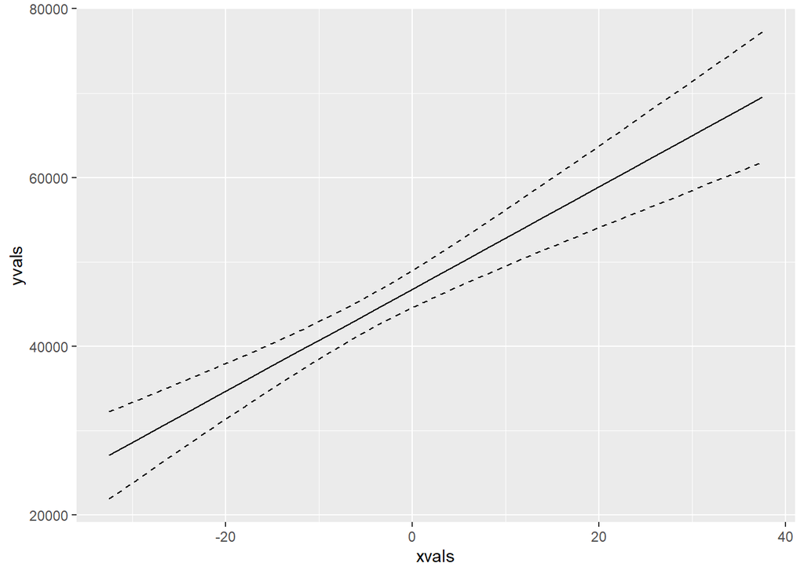

```r
## Predicted Values for real values with "marings"
library(margins)
invisible(age_centr <- cplot(ha4, "age_centr", draw = FALSE))

library(ggplot2)
plottig_1 <- ggplot(age_centr, aes(y=yvals, x = xvals)) +
  geom_line() +
  geom_line(aes(y = upper), linetype = 2) +
  geom_line(aes(y = lower), linetype = 2)
plottig_1
```

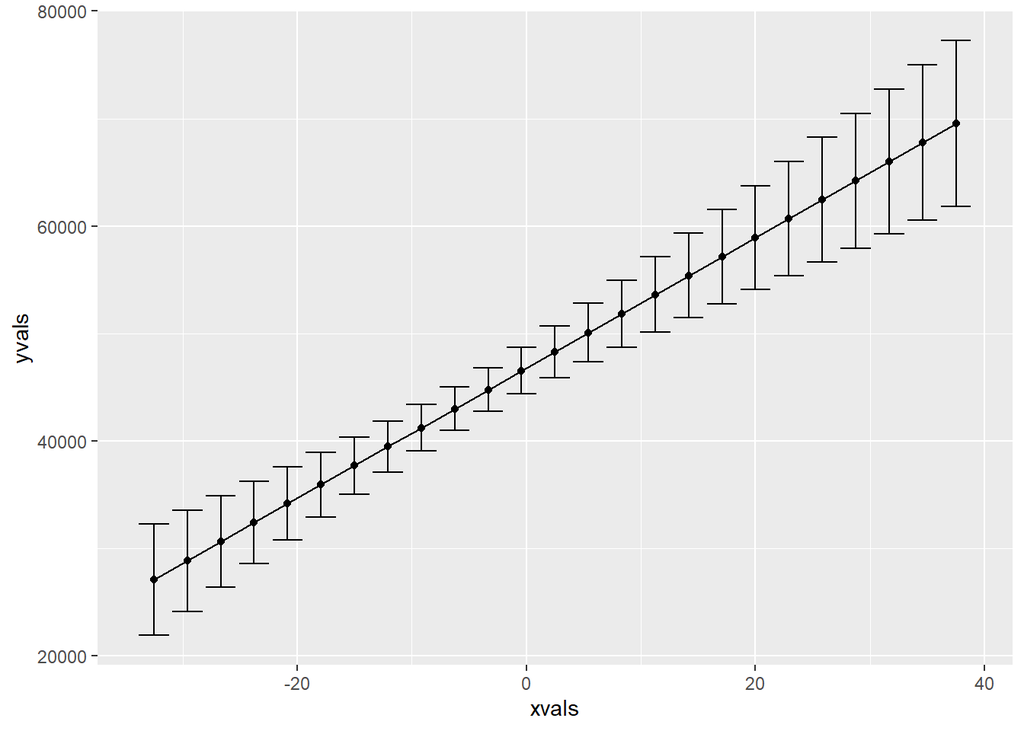

```r
plottig_2 <- ggplot(age_centr, aes(y=yvals, x = xvals)) +
  geom_line() +
  geom_point() +
  geom_errorbar(aes(ymin=lower, ymax=upper))
plottig_2
```

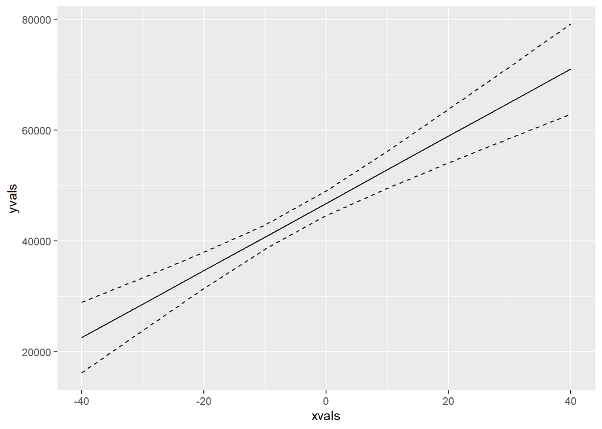

```r
## Predicted Values for set range of values with "marings"
age_centr_2 <- cplot(ha4, "age_centr", draw = FALSE, xvals = seq(from = -40, to =40, by=10))

plottig_3 <- ggplot(age_centr_2, aes(y=yvals, x = xvals)) +
  geom_line() +
  geom_line(aes(y = upper), linetype = 2) +
  geom_line(aes(y = lower), linetype = 2)
plottig_3
```

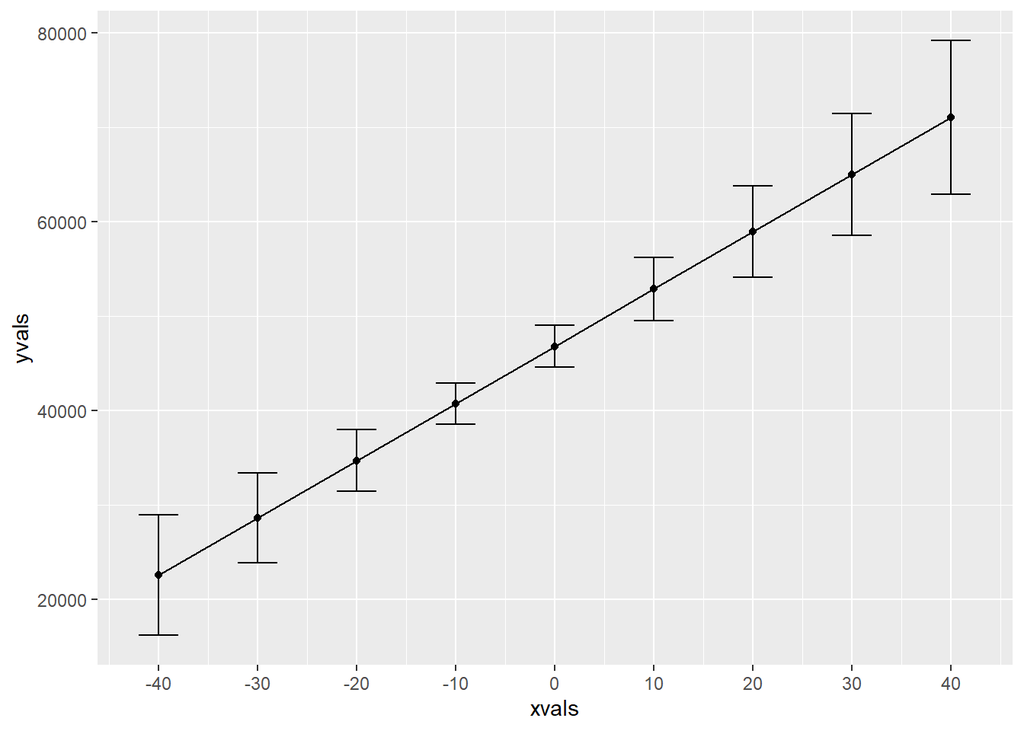

```r
invisible(plottig_4 <- ggplot(age_centr_2, aes(y=yvals, x = xvals)) +
  geom_line() +
  geom_point() +
  geom_errorbar(aes(ymin=lower, ymax=upper),width = 4)+
  xlim(-45, 45) +
  scale_x_continuous(breaks=seq(-40,40,10)))
plottig_4
```

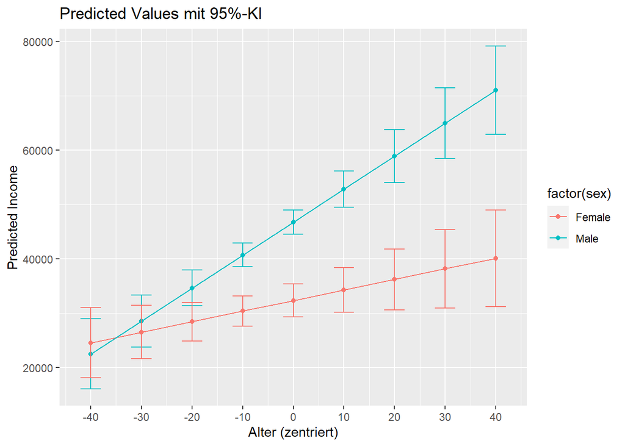

```r
## By-sex
age_centr_Male <- cplot(ha4, "age_centr", draw = FALSE, xvals = seq(from = -40, to =40, by=10), data = data1[data1$sex=="Male",])
age_centr_Male$sex <- "Male"

age_centr_Female <- cplot(ha4, "age_centr", draw = FALSE, xvals = seq(from = -40, to =40, by=10), data = data1[data1$sex=="Female",])
age_centr_Female$sex <- "Female"

age_centr_3 <- bind_rows(age_centr_Male,age_centr_Female)
## Farbig
plottig_5 <- ggplot(age_centr_3, aes(y=yvals, x = xvals, colour=factor(sex))) +
  geom_line() +
  geom_point() +
  geom_errorbar(aes(ymin=lower, ymax=upper),width = 4)+
  xlim(-45, 45) +
  scale_x_continuous(breaks=seq(-40,40,10)) +
  ylab("Predicted Income") +
  xlab("Alter (zentriert)") +
  labs(title = "Predicted Values mit 95%-KI")
plottig_5
```

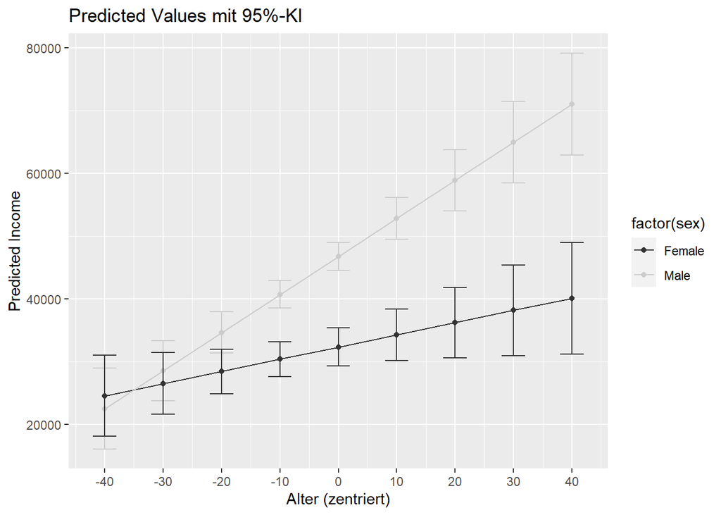

```r
## Grau-Töne
plottig_6 <- ggplot(age_centr_3, aes(y=yvals, x = xvals, colour=factor(sex))) +
  geom_line() +
  geom_point() +
  geom_errorbar(aes(ymin=lower, ymax=upper),width = 4)+
  xlim(-45, 45) +
  scale_x_continuous(breaks=seq(-40,40,10)) +
  ylab("Predicted Income") +
  xlab("Alter (zentriert)") +
  labs(title = "Predicted Values mit 95%-KI") +
  scale_colour_grey()
plottig_6
```

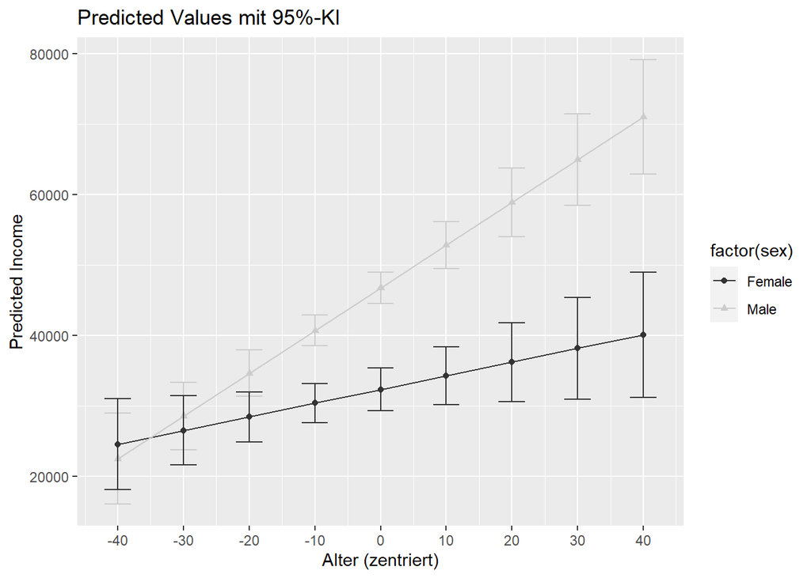

```r
## Grau-Töne mit unterschiedlichen Punkt-Schätzern
plottig_7 <- ggplot(age_centr_3, aes(y=yvals, x = xvals, colour=factor(sex))) +
  geom_line() +
  geom_point(aes(shape = factor(sex))) +
  geom_errorbar(aes(ymin=lower, ymax=upper),width = 4)+
  xlim(-45, 45) +
  scale_x_continuous(breaks=seq(-40,40,10)) +
  ylab("Predicted Income") +
  xlab("Alter (zentriert)") +
  labs(title = "Predicted Values mit 95%-KI") +
  scale_colour_grey()
plottig_7
```

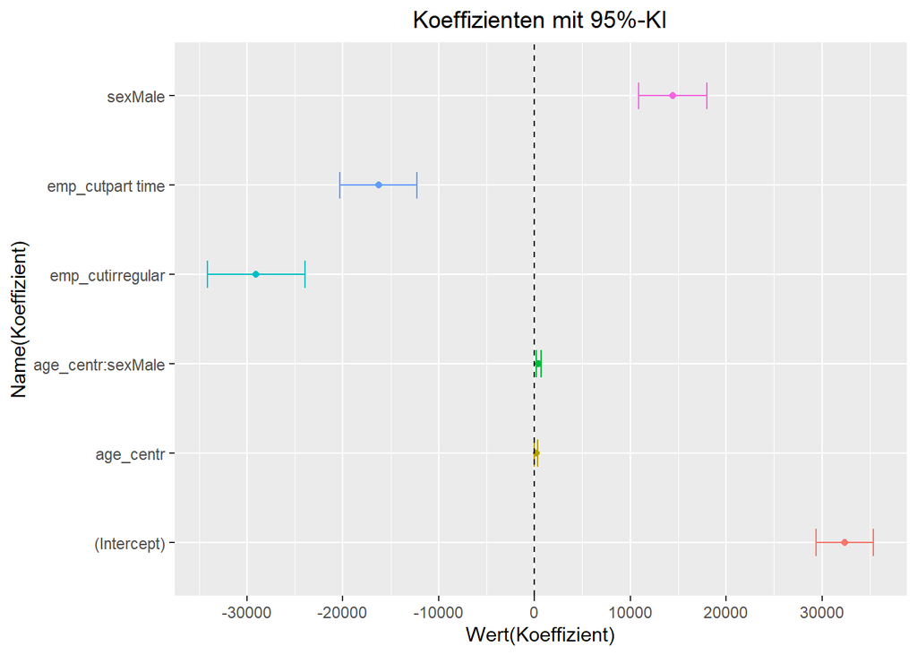

```r
## Forest Plot
ha4_df <- bind_cols(bind_rows(as.data.frame(coef(summary(ha4)))),bind_rows(as.data.frame(names(ha4$coefficients))))
ha4_df$upper <- ha4_df$Estimate + 1.96* ha4_df$`Std. Error`
ha4_df$lower <- ha4_df$Estimate - 1.96* ha4_df$`Std. Error`

plottig_8 <- ggplot(ha4_df, aes(y=`names(ha4$coefficients)`, x = Estimate, color=`names(ha4$coefficients)`)) +
  geom_point() +
  geom_errorbarh(aes(xmin=lower, xmax=upper), height=0.3) +
  ylab("Name(Koeffizient)") +
  xlab("Wert(Koeffizient)") +
  labs(title= "Koeffizienten mit 95%-KI") +
  geom_vline(xintercept=0, linetype="dashed") +
  scale_x_continuous(breaks=seq(-40000,40000,10000))+
  theme(plot.title = element_text(hjust = 0.5)) +
  theme(legend.position = "none")
plottig_8
```

- **Upload the do-file of your solution to Moodle.**

## Hausaufgabe 6

Folgende Aufgaben stammen aus dem [Kohler und Kreuter Buch](https://www.degruyter.com/downloadpdf/title/518369) (2016, S. 404-405):

1. **Laden Sie folgenden Teildatensatz des „National Longitudinal Survey 1988“ in den Arbeitsspeicher: `webuse nlsw88, clear`**

```r
library(Counterfactual)

## Datensatz nun als nlsw88 gespeichert
data(nlsw88)
```

2. **Schätzen Sie die Koeffizienten eines logistischen Regressionsmodells der Variablen `union` gegen folgende unabhängigen Variablen:**
- `tenure` (zentriert)
- `age` (zentriert)
- `collgrad`
- `race`

```r
nlsw88$age_centr <- nlsw88$age - mean(nlsw88$age)
nlsw88$tenure_centr <- nlsw88$tenure - mean(nlsw88$tenure, na.rm=TRUE)

log_reg <- glm(union ~ tenure_centr + age_centr + collgrad + as.factor(race), family = "binomial", data=nlsw88)
summary(log_reg)
```

```
##
## Call:
## glm(formula = union ~ tenure_centr + age_centr + collgrad + as.factor(race),
##     family = "binomial", data = nlsw88)
##
## Deviance Residuals:
##     Min       1Q   Median       3Q      Max
## -1.3027  -0.7637  -0.6447  -0.5682   1.9521
##
## Coefficients:
##                   Estimate Std. Error z value Pr(>|z|)
## (Intercept)      -1.439307   0.077964 -18.461  < 2e-16 ***
## tenure_centr      0.048449   0.009342   5.186 2.15e-07 ***
## age_centr         0.004898   0.018115   0.270 0.786875
## collgrad          0.500384   0.121307   4.125 3.71e-05 ***
## as.factor(race)2  0.445773   0.120416   3.702 0.000214 ***
## as.factor(race)3  0.592559   0.443986   1.335 0.181996
## ---
## Signif. codes:  0 '***' 0.001 '**' 0.01 '*' 0.05 '.' 0.1 ' ' 1
##
## (Dispersion parameter for binomial family taken to be 1)
##
##     Null deviance: 2085.4  on 1867  degrees of freedom
## Residual deviance: 2024.8  on 1862  degrees of freedom
##   (378 observations deleted due to missingness)
## AIC: 2036.8
##
## Number of Fisher Scoring iterations: 4
```

3. **Erstellen Sie eine Variable mit den vorhergesagten Wahrscheinlichkeiten für alle Beobachtungen.**

```r
## Erster Weg
log_reg_up <- update(log_reg,na.action=na.exclude)
nlsw88$yhat <- predict.glm(log_reg_up, type = "response")

## Zweiter Weg
yhat <- as.data.frame(predict.glm(log_reg, type = "response"))
nlsw88 <- merge(nlsw88,yhat, by=0, all=TRUE) ## by=0 -> by = row.names
nlsw88 <- rename(nlsw88, yhat_2 = `predict.glm(log_reg, type = "response")`)
nlsw88 <-  nlsw88[order(nlsw88$idcode),]
head(nlsw88)[,c(21:22)]
```

```
##           yhat    yhat_2
## 1    0.2620566 0.2620566
## 1112 0.2612766 0.2612766
## 1470        NA        NA
## 1581 0.2451001 0.2451001
## 1692 0.2983826 0.2983826
## 1803 0.1651126 0.1651126
```

```r
all.equal(nlsw88$yhat, nlsw88$yhat_2)
```

```
## [1] TRUE
```

4. **Ermitteln Sie die durchschnittlichen geschätzten Odds in einer Gewerkschaft organisiert zu sein für folgende Personengruppen:**
- Befragte mit durchschnittlichem Alter und durchschnittlicher Betriebszugehörigkeit ohne Universitätsabschluss.

```r
## Wegen Intercept automatisch für Weiße!
exp(log_reg$coefficients[["(Intercept)"]])
```

```
## [1] 0.2370919
```

- Schwarze Befragte mit Universitätsabschluss im durchschnittlichen Alter und mit durchschnittlicher Betriebszughörigkeit.

```r
exp(log_reg$coefficients[["(Intercept)"]] + log_reg$coefficients[["as.factor(race)2"]]*1 + log_reg$coefficients[["collgrad"]]*1)
```

```
## [1] 0.6106993
```

- Absolventen mit College-Abschluss.

```r
exp(log_reg$coefficients[["(Intercept)"]] + log_reg$coefficients[["collgrad"]]*1)
```

```
## [1] 0.3910487
```

5. **Ermitteln Sie, wie die geschätzte Wahrscheinlichkeit, in einer Gewerkschaftorganisiert zu sein,für Personen ohne College-Abschluss im durchschnittlichen Alter mit der Betriebszugehörigkeit variiert. Stellen Sie die Wahrscheinlichkeiten grafisch dar.**

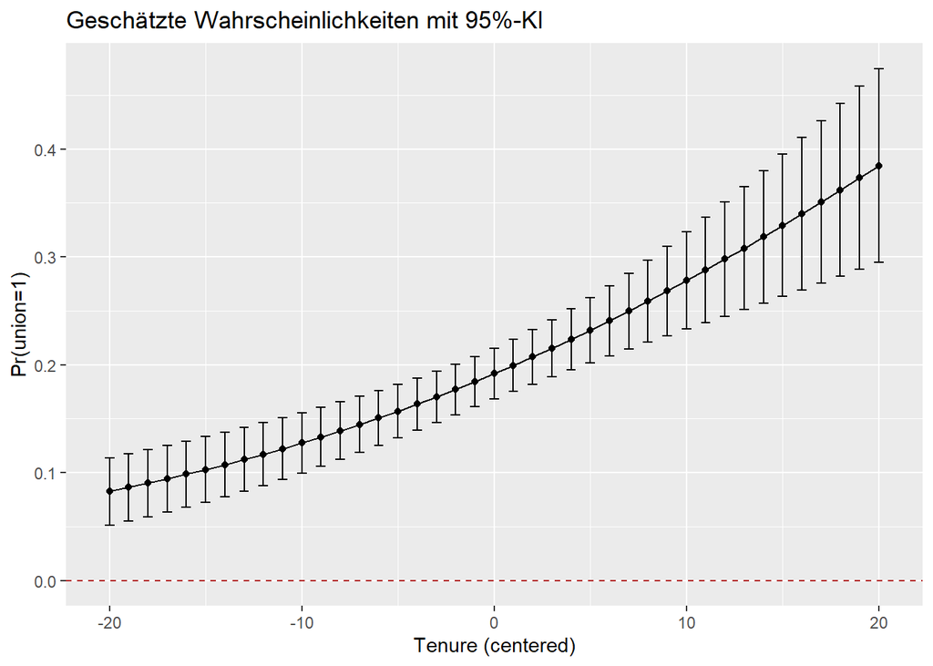

```r
## Tenure Centered
newdata <- data.frame(collgrad = 0, age_centr = 0, tenure_centr = c(-20:20), race = 1)
predict_5<- bind_cols(tenure_centr = c(-20:20), as.data.frame(predict.glm(log_reg, newdata, type="response", se.fit = TRUE)))
predict_5$upper <- predict_5$fit + 1.96 * predict_5$se.fit
predict_5$lower <- predict_5$fit - 1.96 * predict_5$se.fit

## Für tatsächliche Jahre
predict_years <- data.frame(collgrad = 0, age_centr = 0, tenure_centr = c(0:40), race = 1)
predict_years$tenure_centr <- predict_years$tenure_centr - mean(nlsw88$tenure, na.rm=TRUE)
pr <- bind_cols(data.frame(tenure = predict_years$tenure_centr), as.data.frame(predict.glm(log_reg, predict_years, type="response", se.fit = TRUE)))

pr$tenure <- pr$tenure + mean(nlsw88$tenure, na.rm=TRUE)
pr$upper <- pr$fit + 1.96 * pr$se.fit
pr$lower <- pr$fit - 1.96 * pr$se.fit

## PLOTS
plot_log <- ggplot(predict_5, aes(y=fit, x = tenure_centr)) +
  geom_line() +
  geom_point() +
  geom_errorbar(aes(ymin=lower, ymax=upper),width = 0.5)+
  scale_x_continuous(breaks=seq(-20,20,10)) +
  ylab("Pr(union=1)") +
  xlab("Tenure (centered)") +
  labs(title = "Geschätzte Wahrscheinlichkeiten mit 95%-KI") +
  scale_colour_grey() +
  geom_hline(yintercept=0, linetype="dashed", color = "firebrick")
plot_log
```

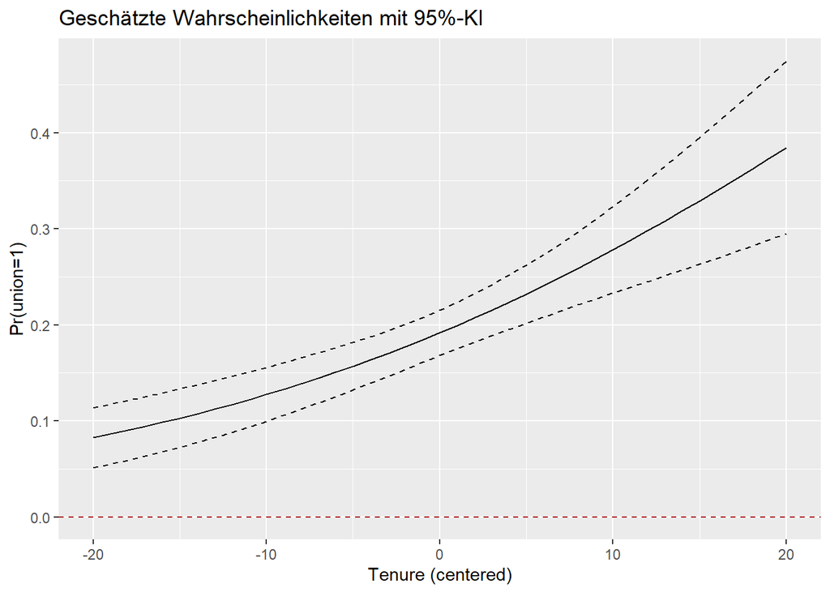

```r
plot_log_2 <- ggplot(predict_5, aes(y=fit, x = tenure_centr)) +
  geom_line() +
  geom_line(aes(y = upper), linetype = 2) +
  geom_line(aes(y = lower), linetype = 2) +
  ylab("Pr(union=1)") +
  xlab("Tenure (centered)") +
  labs(title = "Geschätzte Wahrscheinlichkeiten mit 95%-KI") +
  scale_colour_grey() +
  geom_hline(yintercept=0, linetype="dashed", color = "firebrick")
plot_log_2
```

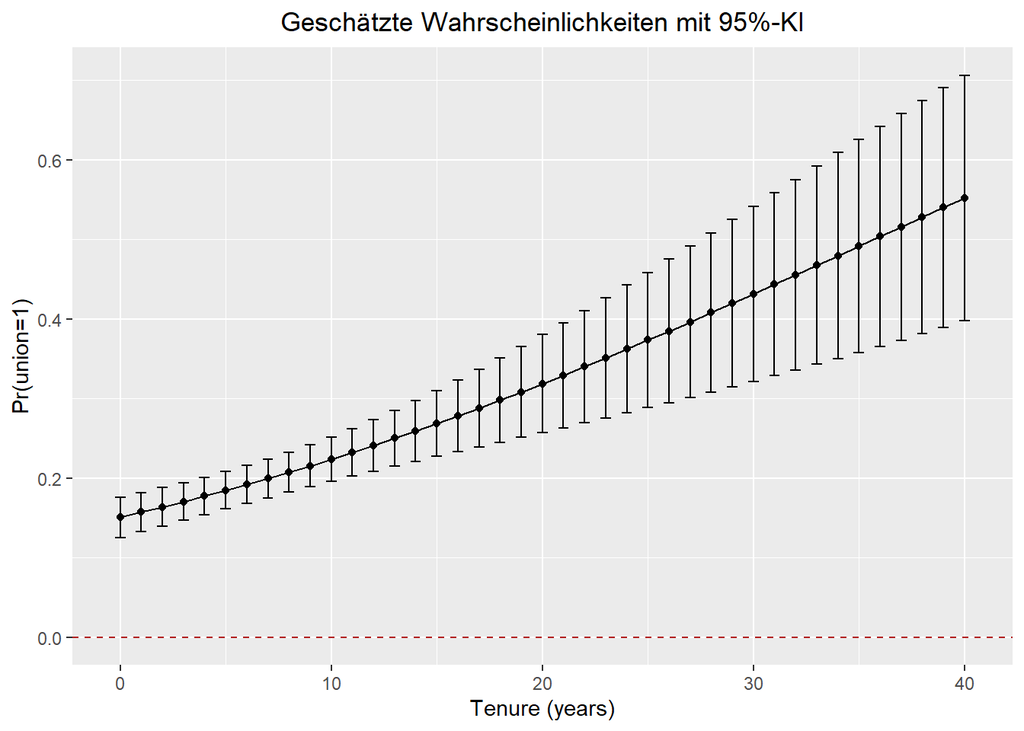

```r
plot_log_3 <- ggplot(pr, aes(y=fit, x = tenure)) +
  geom_line() +
  geom_point() +
  geom_errorbar(aes(ymin=lower, ymax=upper),width = 0.5)+
  scale_x_continuous(breaks=seq(0,40,10)) +
  ylab("Pr(union=1)") +
  xlab("Tenure (years)") +
  labs(title = "Geschätzte Wahrscheinlichkeiten mit 95%-KI") +
  scale_colour_grey() +
  geom_hline(yintercept=0, linetype="dashed", color = "firebrick") +
  theme(plot.title = element_text(hjust = 0.5))
plot_log_3
```

6. **Schätzen Sie entsprechende Wahrscheinlichkeit für Befragte mit einem College-Abschluss. Fügen Sie Ihrer Grafik eine Linie für diese Wahrscheinlichkeiten hinzu.**

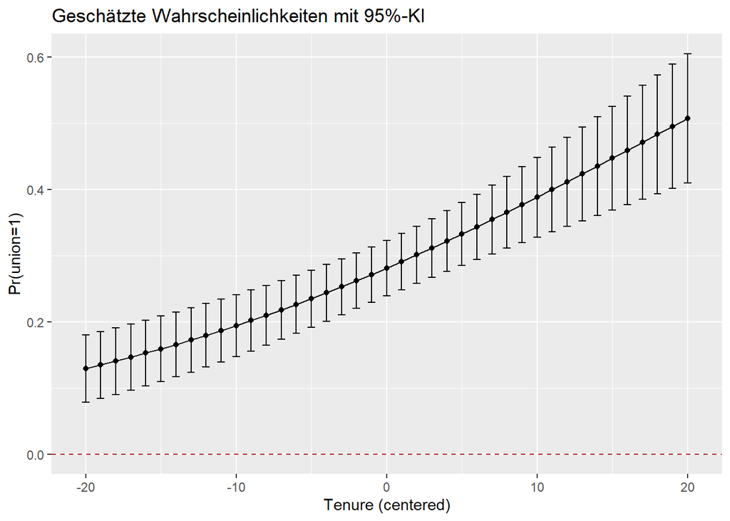

```r
newdata_2 <- data.frame(collgrad = 1, age_centr = 0, tenure_centr = c(-20:20), race = 1)
predict_6<- bind_cols(tenure_centr = c(-20:20), as.data.frame(predict.glm(log_reg, newdata_2, type="response", se.fit = TRUE)))

predict_6$upper <- predict_6$fit + 1.96 * predict_6$se.fit
predict_6$lower <- predict_6$fit - 1.96 * predict_6$se.fit

plot_log_4 <- ggplot(predict_6, aes(y=fit, x = tenure_centr)) +
  geom_line() +
  geom_point() +
  geom_errorbar(aes(ymin=lower, ymax=upper),width = 0.5)+
  scale_x_continuous(breaks=seq(-20,20,10)) +
  ylab("Pr(union=1)") +
  xlab("Tenure (centered)") +
  labs(title = "Geschätzte Wahrscheinlichkeiten mit 95%-KI") +
  scale_colour_grey() +
  geom_hline(yintercept=0, linetype="dashed", color = "firebrick")
plot_log_4
```

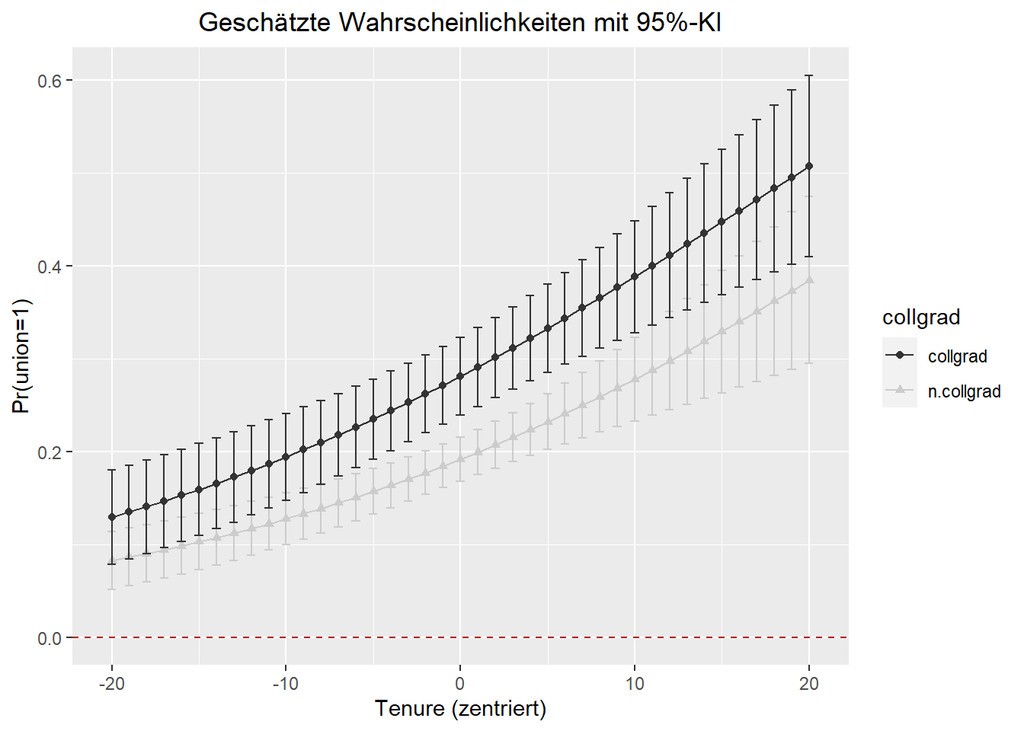

```r
comb <- bind_rows(predict_5, predict_6)
comb$collgrad <- ""
comb[c(1:41), 7] <- "n.collgrad"
comb[c(42:82), 7] <- "collgrad"

plot_log_5 <- ggplot(comb, aes(y=fit, x = tenure_centr, colour=collgrad)) +
  geom_line() +
  geom_point(aes(shape = collgrad)) +
  geom_errorbar(aes(ymin=lower, ymax=upper),width = 0.5)+
  scale_x_continuous(breaks=seq(-20,20,10)) +
  ylab("Pr(union=1)") +
  xlab("Tenure (zentriert)") +
  labs(title = "Geschätzte Wahrscheinlichkeiten mit 95%-KI") +
  scale_colour_grey() +
  geom_hline(yintercept=0, linetype="dashed", color = "firebrick") +
  theme(plot.title = element_text(hjust = 0.5))
plot_log_5
```

7. **Untersuchen Sie die funktionale Form des Effektes der Betriebszugehörigkeit. Ist der Zusammenhang linear?**

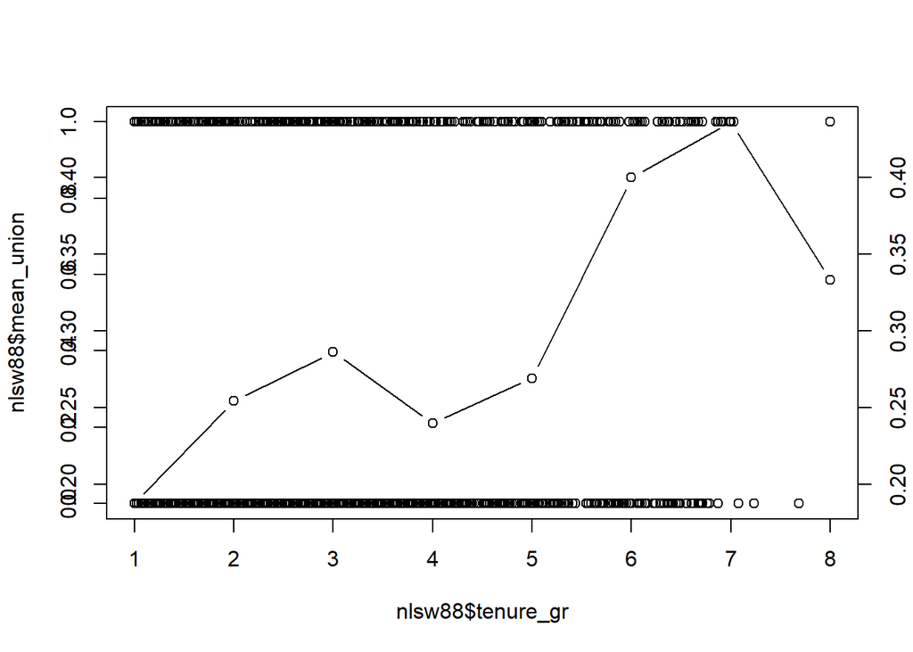

```r
## Des Durchschnitts für Tenure
# Tenure in Gruppen
nlsw88$tenure_gr <- as.numeric(cut(nlsw88$tenure, 8))

# Durchschnitt von Union über Gruppe
tenure_gr <- as.data.frame(aggregate(x = nlsw88$union, by = list(tenure_gr=nlsw88$tenure_gr), FUN = mean, na.rm=TRUE))
nlsw88 <- merge(nlsw88,tenure_gr, all = TRUE)
nlsw88 <- rename(nlsw88, mean_union = x)

nlsw88$tenure_gr <- as.numeric(nlsw88$tenure_gr)
nlsw88$mean_union <- as.numeric(nlsw88$mean_union)

## Plots
plot(nlsw88$tenure, nlsw88$union , xaxt='n', ann=FALSE)
par(new=TRUE)
plot(nlsw88$tenure_gr, nlsw88$mean_union, type="b")
axis(side = 4)
```

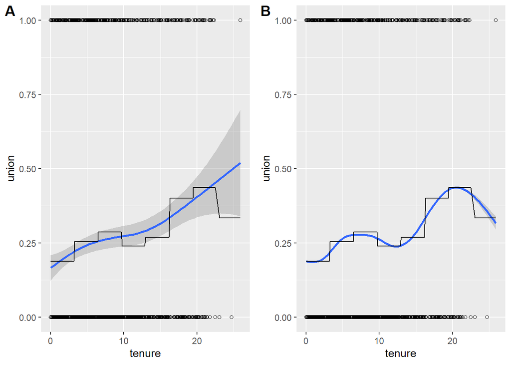

```r
# Smoothing über Union Zugehörigkeit und Tenure
func_plot <- ggplot(nlsw88, aes(y=union, x=tenure)) +
  geom_point(shape=1) +
  geom_smooth(aes(x=tenure, y=union)) +
  geom_line(aes(x=tenure, y=mean_union))

# Smoothing über Mean(Union Zugehörigkeit) und Tenure
func_plot_2 <- ggplot(nlsw88, aes(y=union, x=tenure)) +
  geom_point(shape=1) +
  geom_smooth(aes(x=tenure, y=mean_union)) +
  geom_line(aes(x=tenure, y=mean_union))

invisible(library(ggpubr))
ggarrange(func_plot, func_plot_2,
          labels = c("A" , "B"),
          ncol = 2, nrow = 1)
```

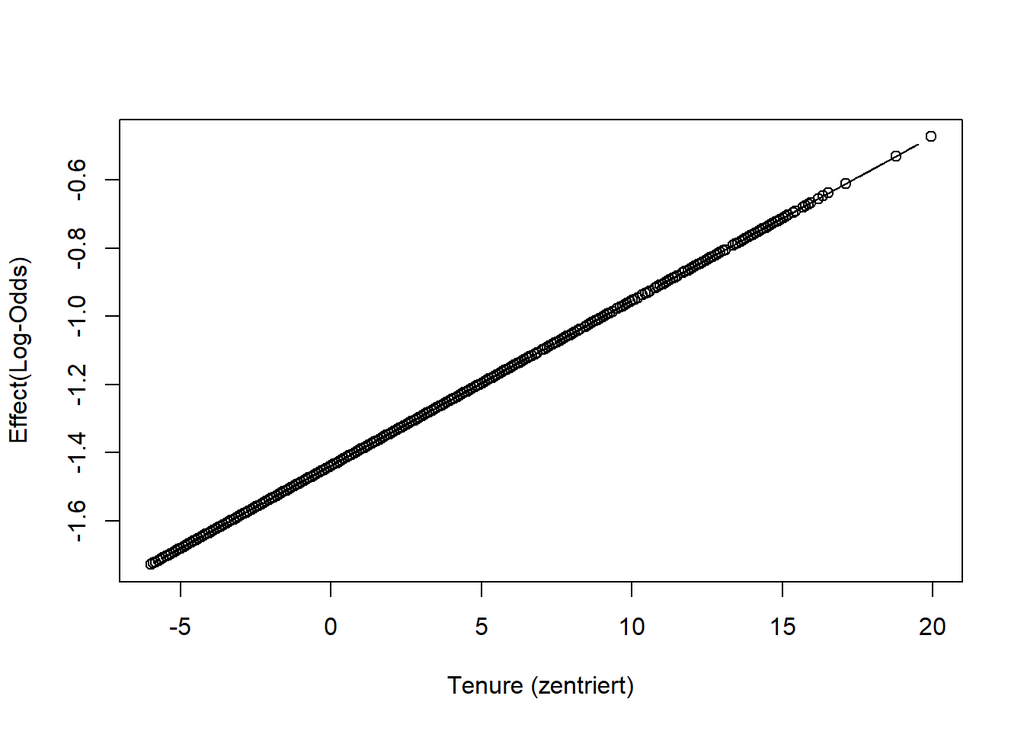

```r
## Der Effekte
plot(nlsw88$tenure_centr, log_reg$coefficients[["(Intercept)"]]+log_reg$coefficients[["tenure_centr"]]*nlsw88$tenure_centr, type="b", xlab = "Tenure (zentriert)", ylab = "Effect(Log-Odds)")
```

8. **Erstellen Sie eine Klassifikationstabelle; nutzen Sie dazu zunächst die vorhergesagten Wahrscheinlichkeiten, danach den Stata-Befehl `estat classification`.**

```r
## Über vohergesagte Wahrscheinlichkeiten
nlsw88$yhat_indic <- ifelse(nlsw88$yhat<0.5, 0, 1)
klasifikation <- table(nlsw88$yhat_indic, nlsw88$union)
klasifikation
```

```
##
##        0    1
##   0 1401  456
##   1    7    4
```

```r
prop.table(klasifikation, 1)
```

```
##
##             0         1
##   0 0.7544426 0.2455574
##   1 0.6363636 0.3636364
```

```r
prop.table(klasifikation, 2)
```

```
##
##               0           1
##   0 0.995028409 0.991304348
##   1 0.004971591 0.008695652
```

```r
## Zweiter Weg
classDF <- data.frame(response = nlsw88$union, predicted = nlsw88$yhat_indic)
xtabs(~ predicted + response, data = classDF)
```

```
##          response
## predicted    0    1
##         0 1401  456
##         1    7    4
```

```r
## Ahmen wir den Stata Befehl nach!
# Tabelle
class_1 <- as.matrix(klasifikation)
rownames(class_1) <- c("Predic. 0", "Predic. 1")
colnames(class_1) <- c("True 0", "True 1")
# Sensitivity (true positives)
class_2 <- (class_1[2,2]/(class_1[2,2]+class_1[1,2]))*100
names(class_2) <- "Sensitivity %"

# Specificity (true negatives)
class_3 <- (class_1[1,1]/(class_1[1,1]+class_1[2,1]))*100
names(class_3) <- "Specificity %"

# False Positives // Einfacher 100 - Sensitivity
class_4 <- (class_1[2,1]/(class_1[1,1]+class_1[2,1]))*100
names(class_4) <- "False Positives"

# False Negatives // Einfacher 100 - Specificity
class_5 <- (class_1[1,2]/(class_1[2,2]+class_1[1,2]))*100
names(class_5) <- "False Negatives"

# R²-Count - Correctly Classified
class_6 <- ((class_1[1,1]+class_1[2,2])/sum(class_1))*100
names(class_6) <- "R²-Count"

# Adjusted R²-Count - Correctly Classified
class_7 <- (((class_1[1,1]+class_1[2,2])-max(colSums(class_1)))/((sum(class_1))-max(colSums(class_1))))*100
names(class_7) <- "Adj. R²-Count"

estat_classification <- list(class_1,class_2,class_3, class_4, class_5, class_6, class_7)
estat_classification
```

```
## [[1]]
##
##             True 0 True 1
##   Predic. 0   1401    456
##   Predic. 1      7      4
##
## [[2]]
## Sensitivity %
##     0.8695652
##
## [[3]]
## Specificity %
##      99.50284
##
## [[4]]
## False Positives
##       0.4971591
##
## [[5]]
## False Negatives
##        99.13043
##
## [[6]]
## R²-Count
## 75.21413
##
## [[7]]
## Adj. R²-Count
##    -0.6521739
```

```r
## Oder mit meinem eigens geschriebenen Paket. Bitte an o.g. Email kontaktieren für Source File
library(estatclass)
estat_class(log_reg, nlsw88$union, 0.5)
```

```
## [[1]]
##            dep.var
## predictions True 0 True 1
##   Predic. 0   1401    456
##   Predic. 1      7      4
##
## [[2]]
## Sensitivity or true positive rate (TPR) %
##                                 0.8695652
##
## [[3]]
## Specificity or true negative rate (TNR) %
##                                  99.50284
##
## [[4]]
## Miss rate or false negative rate (FNR) %
##                                 99.13043
##
## [[5]]
## Fall-out or false positive rate (FPR) %
##                               0.4971591
##
## [[6]]
## Precision or positive predictive value (PPV) %
##                                       36.36364
##
## [[7]]
## False discovery rate (FDR) %
##                     63.63636
##
## [[8]]
## R²-Count or accuracy (ACC) %
##                     75.21413
##
## [[9]]
## Adj. R²-Count % (Long 1997: 108)
##                       -0.6521739
```

```r
extat_class(log_reg, nlsw88$union, 0.5)
```

```
## [[1]]
##            dep.var
## predictions True 0 True 1
##   Predic. 0   1401    456
##   Predic. 1      7      4
##
## [[2]]
## Sensitivity or true positive rate (TPR) %
##                                 0.8695652
##
## [[3]]
## Specificity or true negative rate (TNR) %
##                                  99.50284
##
## [[4]]
## miss rate or false negative rate (FNR) %
##                                 99.13043
##
## [[5]]
## fall-out or false positive rate (FPR) %
##                               0.4971591
##
## [[6]]
## Precision or positive predictive value (PPV) %
##                                       36.36364
##
## [[7]]
## false discovery rate (FDR) %
##                     63.63636
##
## [[8]]
## R²-Count or accuracy (ACC) %
##                     75.21413
##
## [[9]]
## Adj. R²-Count % (Long 1997: 108)
##                       -0.6521739
##
## [[10]]
## F1 score
## 1.698514
##
## [[11]]
## balanced accuracy (BA) or balanced R²-Count %
##                                       50.1862
##
## [[12]]
## Matthews correlation coefficient (MCC)
##                             0.02096982
##
## [[13]]
## Fowlkes–Mallows index (FM)
##                   5.623216
##
## [[14]]
## informedness or bookmaker informedness (BM)
##                                   0.3724061
##
## [[15]]
## markedness (MK) or deltaP
##                   11.8079
```

9. **Führen Sie einen „Likelihood-Ratio-Test“ für den Einfluss des Alters durch. Was folgt aus diesem Test?**

$\mathcal{X}^2_{\mathcal{L}(Diff)} = -2(ln\mathcal{L}_{ohne} - ln\mathcal{L}_{mit})$

```r
full_model <- log_reg
reduced_model <-glm(union ~ tenure_centr + collgrad + as.factor(race), family = "binomial", data=nlsw88)

#### Ohne Extra Paket
chisqr_diff <- -2*(as.numeric(logLik(reduced_model))-as.numeric(logLik(log_reg)))
chisqr_diff
```

```
## [1] 0.07307636
```

```r
# Geringe Differenz = Kaum Verbesserung

##Berechnung der DF für die Differenz der Modelle (können Differnz der Koeffizientenzahl nehmen =1)
length(coef(full_model)) - length(coef(reduced_model))
```

```
## [1] 1
```

```r
pchisq(chisqr_diff,df=1,lower.tail=FALSE) ## p-Value = 0.7869092, insignifikant
```

```
## [1] 0.7869092
```

```r
#### Mit Packet
library(lmtest)
lrtest (reduced_model, full_model)
```

```
## Likelihood ratio test
##
## Model 1: union ~ tenure_centr + collgrad + as.factor(race)
## Model 2: union ~ tenure_centr + age_centr + collgrad + as.factor(race)
##   #Df  LogLik Df  Chisq Pr(>Chisq)
## 1   5 -1012.4
## 2   6 -1012.4  1 0.0731     0.7869
```

Der $Pr>\mathcal{X}^2$ Wert ist weitaus größer als 0,05. Die Null-Hypothese ($H_0$), welche hier annimmt, dass der Effekt des Alters in der Grundgesamtheit 0 beträgt, kann nicht verworfen werden. Die Wahrscheinlichkeit jene Log-Likelihood für das Modell zu erhalten, wenn der Effekt auf Null gesetzt wird, ist knapp 79%. Dies ist ein hoher Wert. Dieser Fakt, als auch die relativ geringe Differenz in den Log-Likehoods der beiden Modelle (welche letztlich jenen hohen $Pr>\mathcal{X}^2$ Wert beanstandet hat), zeigt, dass das Hinzunehmen des Alters kaum zur Verbesserung des Modelfits beigetragen hat.

10. **Erstellen Sie einen Scatterplot von $\Deltaχ^2$ gegen die vorhergesagten Wahrscheinlichkeiten. Beschriften Sie die Markersymbole mit dem Kovariaten-Muster. Welche Schlussfolgerung ziehen Sie aus der Analyse?**

Formeln aus Hosmer, Lemeshow und Sturdivant: Appliead Logistic Regression (2013, S. 191)  
Pearson-Residuen: $r_j$  
Standardisierte Pearson-Residuen: $r_{sj}=\frac{r_j}{\sqrt{1-h_j}}$  
Delta-Chi²: $\Deltaχ_j^2=\frac{r_j^2}{{1-h_j}}=r_{sj}^2$

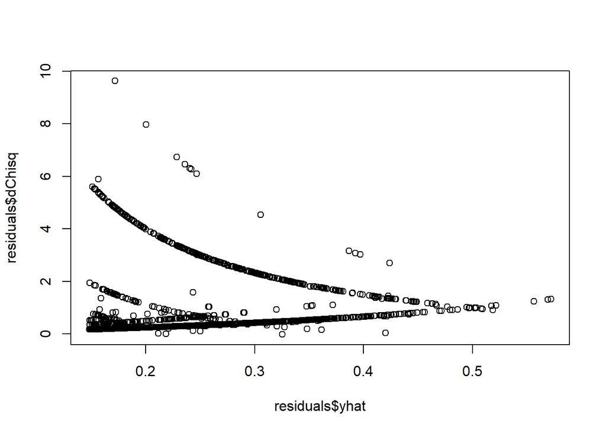

```r
### Ohne Packet
#Perason Residuen (r)
pr <- residuals.glm(log_reg, "pearson")
# Leverage (H)
h <- hatvalues(log_reg)
# Predicted probabilities
yhat <- predict.glm(log_reg, type="response")

# Zusammenführung der Daten
residuals <- bind_cols(as.data.frame(yhat), as.data.frame(pr), as.data.frame(h))

# Aggregate um für die vielfachen yhats einheitliche Werte zu gewinnen
# Zuvor die Anzahl der einzelnen Werte (n) für yhat sichern
n <- count(residuals, vars = c(yhat))
n <- rename(n, yhat = vars)
residuals <- aggregate(residuals, by=list(yhat), FUN=mean)

# Zusammenführung aller Informationen
residuals <- merge(residuals, n, all = TRUE)
residuals <- residuals[,-2]

#Standardisierte Pearson-Residuen
residuals$spr <- residuals$pr/sqrt(1 - residuals$h)

#Delta-Chi²
residuals$dChisq <- (residuals$pr)^2/1 - residuals$h
#Wir müssen mit der Zahl (n) der yhats multiplizieren, weil wir durch aggregate durch n dividiert haben
residuals$dChisq <- residuals$dChisq*residuals$n

# Plotten - Wie markieren wir aber einflussreiche Fälle?
plot(residuals$yhat, residuals$dChisq)
```

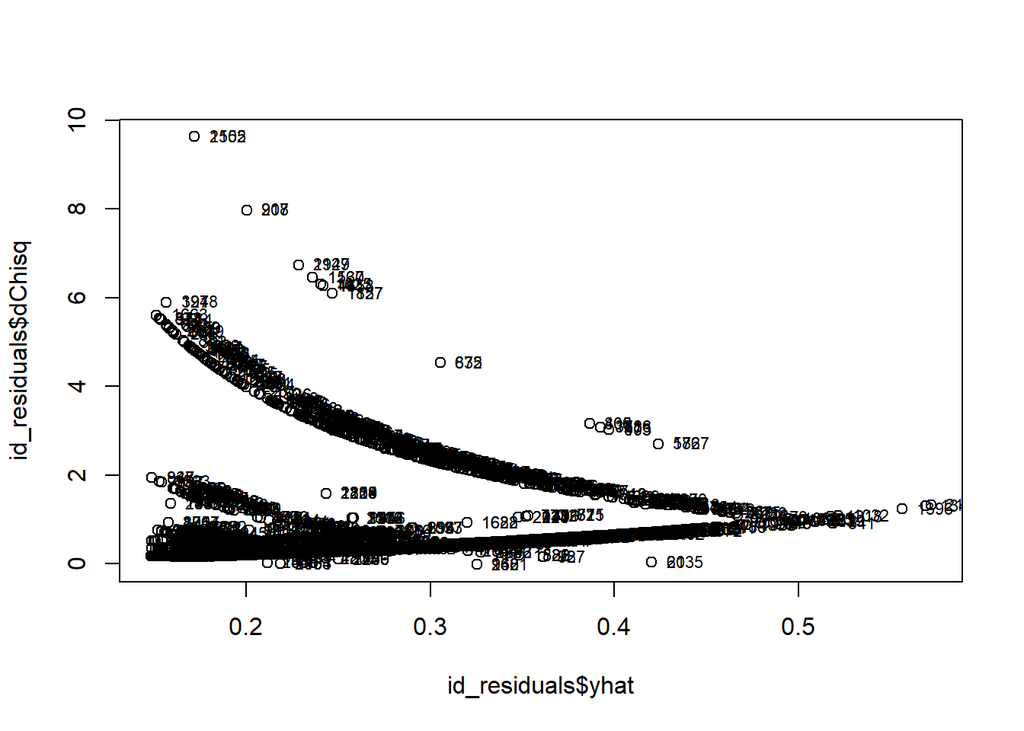

```r
id_residuals <- merge(residuals, nlsw88, all=TRUE)
## Notiz: Durch das mergen, differenzieren sich die Fälle wieder auf
plot(id_residuals$yhat, id_residuals$dChisq)
text(id_residuals$yhat, id_residuals$dChisq, labels=id_residuals$Row.names, cex= 0.7, pos=4)
```

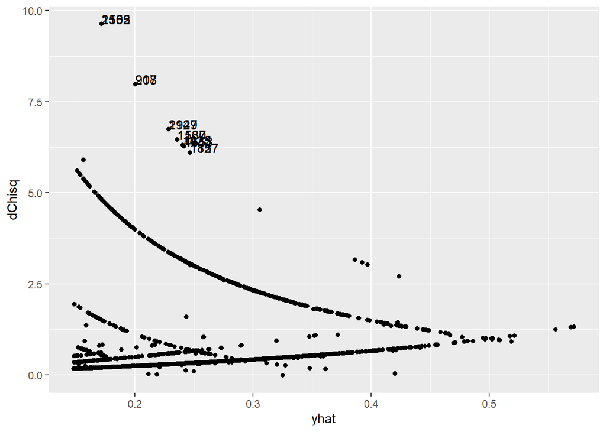

```r
##Schöner mit GGPlot - Alle mit dChisq größer als 6
ggplot(id_residuals, aes(y=dChisq, x=yhat, label=Row.names)) +
  geom_point() +
  geom_text(aes(label=ifelse(dChisq>6, Row.names,'')), hjust=0, vjust=0)
```

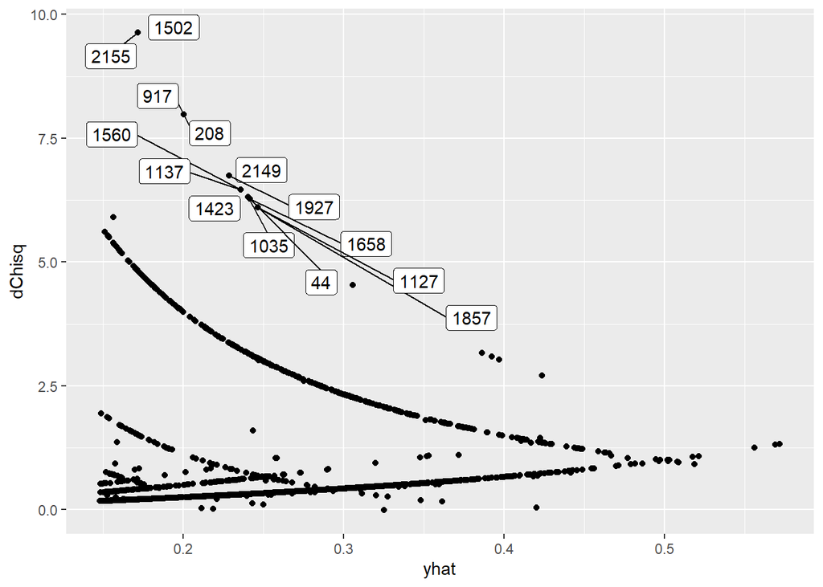

```r
# Mit ggrepel
library(ggrepel)
ggplot(id_residuals, aes(y=dChisq, x=yhat, label=Row.names)) +
  geom_point() +
  geom_label_repel(aes(label=ifelse(dChisq>6, Row.names,'')))
```

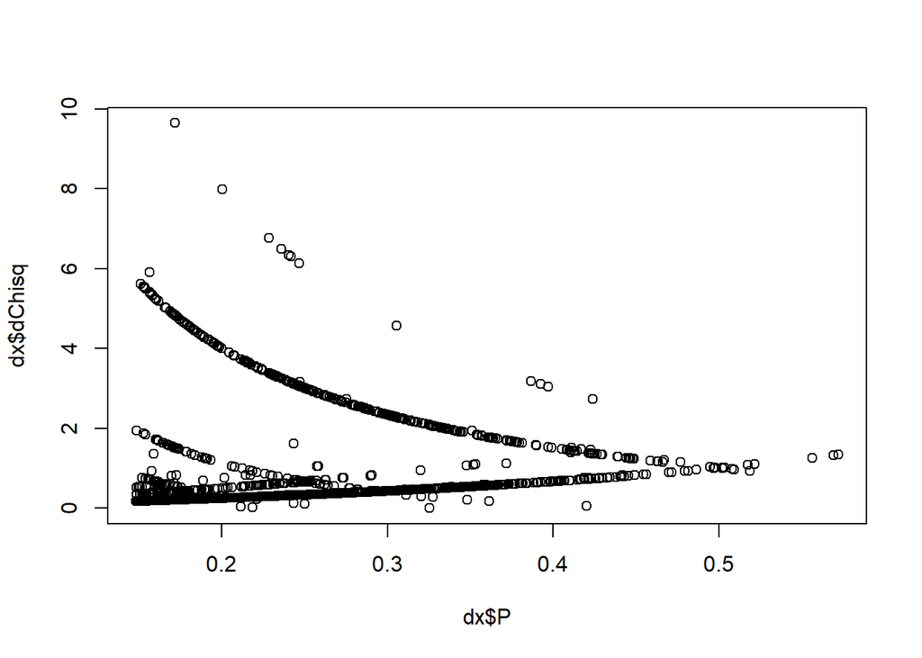

```r
#### Mit Packet
library(LogisticDx)
dx <- dx(log_reg)
plot(dx$P, dx$dChisq)
```

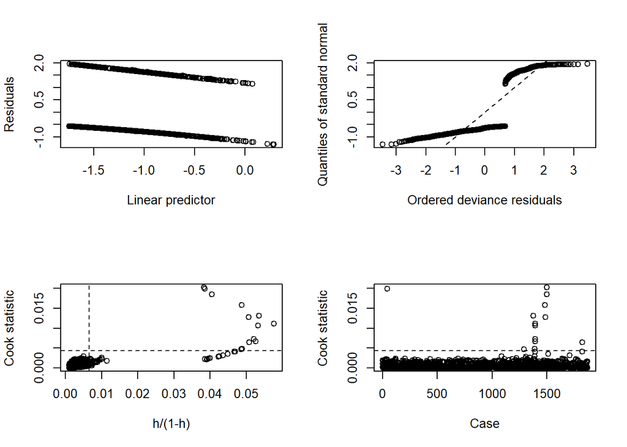

```r
# Interessant
library(boot)
glm.diag.plots(log_reg, glmdiag = glm.diag(log_reg))
```

11. **Untersuchen Sie die Zusammenhang zwischen den „High-Influence-Points“ und dem Wirtschaftssektor (`industry`). Was schließen Sie daraus? Führen Sie eine Kontrollvariable mit den Kategorien Urproduktion, industrieller Sektor, Dienstleistungssektor in das Modell ein und interpretieren Sie die Veränderung der geschätzten Koeffizienten.**

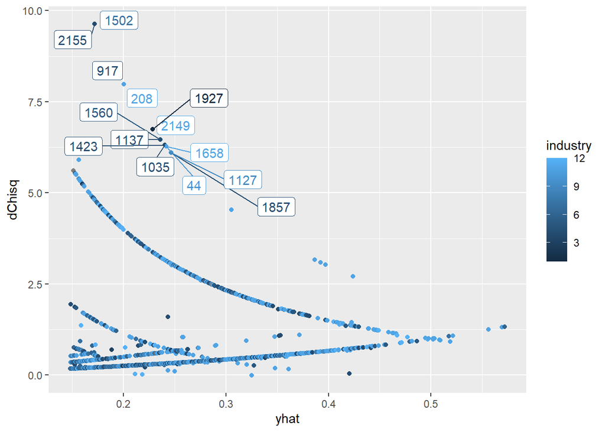

```r
ggplot(id_residuals, aes(y=dChisq, x=yhat, label=Row.names, color=industry)) +
  geom_point() +
  geom_label_repel(aes(label=ifelse(dChisq>6, Row.names,'')))
```

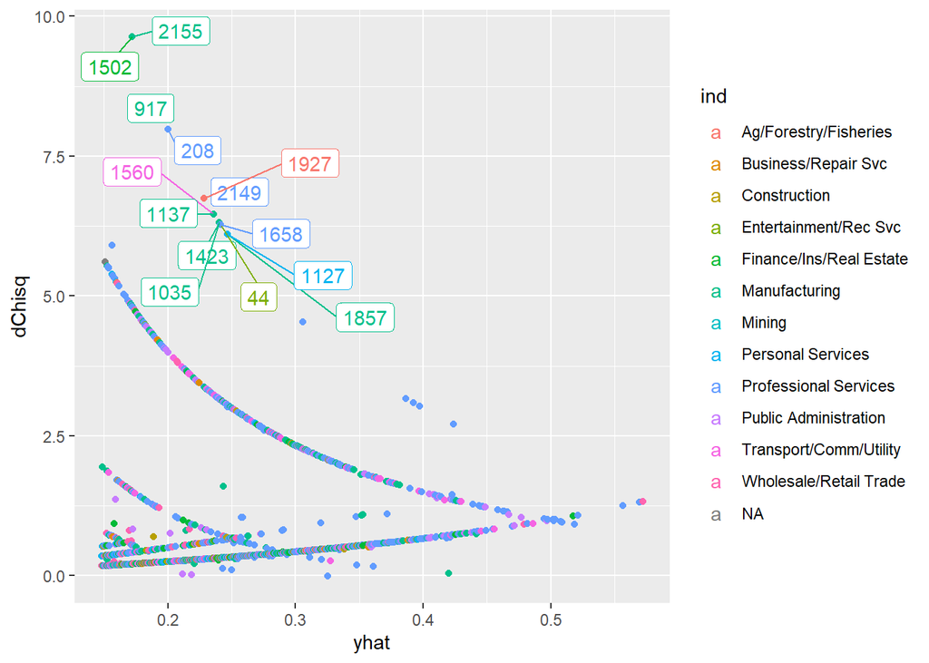

```r
id_residuals$ind[id_residuals$industry==1] <- "Ag/Forestry/Fisheries"
id_residuals$ind[id_residuals$industry==2] <- "Mining"
id_residuals$ind[id_residuals$industry==3] <- "Construction"
id_residuals$ind[id_residuals$industry==4] <- "Manufacturing"
id_residuals$ind[id_residuals$industry==5] <- "Transport/Comm/Utility"
id_residuals$ind[id_residuals$industry==6] <- "Wholesale/Retail Trade"
id_residuals$ind[id_residuals$industry==7] <- "Finance/Ins/Real Estate"
id_residuals$ind[id_residuals$industry==8] <- "Business/Repair Svc"
id_residuals$ind[id_residuals$industry==9] <- "Personal Services"
id_residuals$ind[id_residuals$industry==10] <- "Entertainment/Rec Svc"
id_residuals$ind[id_residuals$industry==11] <- "Professional Services"
id_residuals$ind[id_residuals$industry==12] <- "Public Administration"

ggplot(id_residuals, aes(y=dChisq, x=yhat, label=Row.names, color=ind)) +
  geom_point() +
  geom_label_repel(aes(label=ifelse(dChisq>6, Row.names,'')))
```

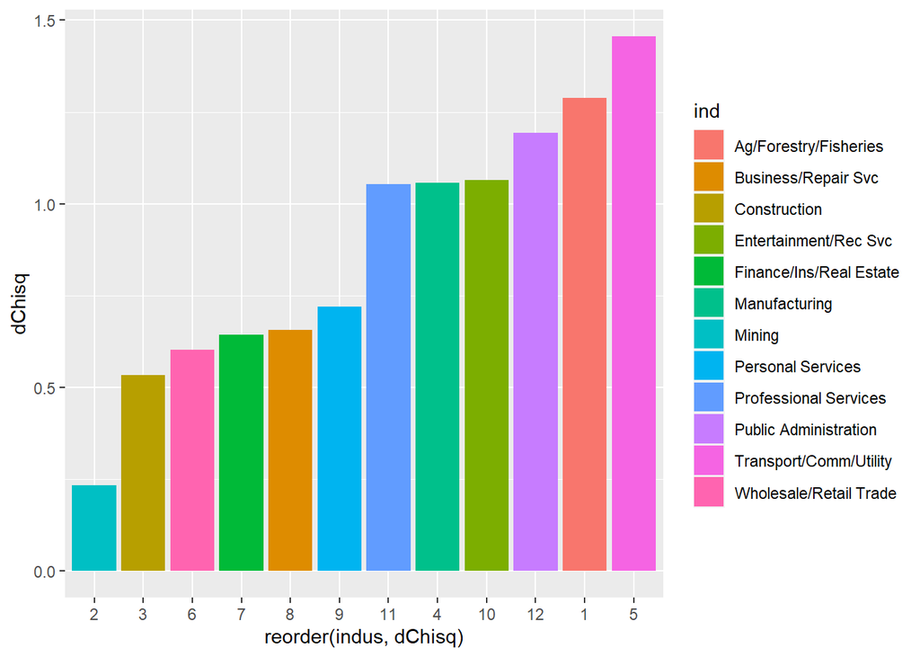

```r
barplot <- dplyr::select(id_residuals, dChisq, industry)
barplot<- aggregate(x=list(dChisq=barplot$dChisq), by=list(industry=barplot$industry), FUN=mean, na.rm=TRUE)
barplot$ind[barplot$industry==1] <- "Ag/Forestry/Fisheries"
barplot$ind[barplot$industry==2] <- "Mining"
barplot$ind[barplot$industry==3] <- "Construction"
barplot$ind[barplot$industry==4] <- "Manufacturing"
barplot$ind[barplot$industry==5] <- "Transport/Comm/Utility"
barplot$ind[barplot$industry==6] <- "Wholesale/Retail Trade"
barplot$ind[barplot$industry==7] <- "Finance/Ins/Real Estate"
barplot$ind[barplot$industry==8] <- "Business/Repair Svc"
barplot$ind[barplot$industry==9] <- "Personal Services"
barplot$ind[barplot$industry==10] <- "Entertainment/Rec Svc"
barplot$ind[barplot$industry==11] <- "Professional Services"
barplot$ind[barplot$industry==12] <- "Public Administration"

barplot$indus <- as.character(barplot$industry)

ggplot(barplot, aes(y=dChisq, x=reorder(indus, dChisq), fill=ind)) +
  geom_bar(stat = "identity")
```

```r
nlsw88$ind_cut[between(nlsw88$industry,1,2)] <- "Urproduktion"
nlsw88$ind_cut[between(nlsw88$industry,3,6)] <- "Industrieller Sektor"
nlsw88$ind_cut[between(nlsw88$industry,7,12)] <- "Dienstleistungssektor"

log_reg <- glm(union ~ tenure_centr + age_centr + collgrad + as.factor(race) + as.factor(ind_cut), family = "binomial", data=nlsw88)
summary(log_reg)
```

```
##
## Call:
## glm(formula = union ~ tenure_centr + age_centr + collgrad + as.factor(race) +
##     as.factor(ind_cut), family = "binomial", data = nlsw88)
##
## Deviance Residuals:
##     Min       1Q   Median       3Q      Max
## -1.3007  -0.7674  -0.6411  -0.5578   2.1502
##
## Coefficients:
##                                         Estimate Std. Error z value Pr(>|z|)
## (Intercept)                            -1.405677   0.093280 -15.069  < 2e-16
## tenure_centr                            0.047671   0.009399   5.072 3.94e-07
## age_centr                               0.003630   0.018182   0.200 0.841737
## collgrad                                0.477159   0.126119   3.783 0.000155
## as.factor(race)2                        0.460152   0.120759   3.811 0.000139
## as.factor(race)3                        0.587348   0.443692   1.324 0.185578
## as.factor(ind_cut)Industrieller Sektor -0.076480   0.119381  -0.641 0.521760
## as.factor(ind_cut)Urproduktion         -0.587240   0.774654  -0.758 0.448411
##
## (Intercept)                            ***
## tenure_centr                           ***
## age_centr
## collgrad                               ***
## as.factor(race)2                       ***
## as.factor(race)3
## as.factor(ind_cut)Industrieller Sektor
## as.factor(ind_cut)Urproduktion
## ---
## Signif. codes:  0 '***' 0.001 '**' 0.01 '*' 0.05 '.' 0.1 ' ' 1
##
## (Dispersion parameter for binomial family taken to be 1)
##
##     Null deviance: 2071.3  on 1854  degrees of freedom
## Residual deviance: 2010.4  on 1847  degrees of freedom
##   (391 observations deleted due to missingness)
## AIC: 2026.4
##
## Number of Fisher Scoring iterations: 4
```